# 2025 Lin et al. Figures

C Ryan Miller Lab @ UAB

Benjamin Lin

Last modified: 10 Aug 2025

This R Markdown (RMD) file generates figures for the 2025 Lin manuscript.  
https://github.com/benlin-UAB/2025_Lin_ComboSyntheticLethality_Manuscript

# Setup

This code section starts script timing, loads R libraries, sets file directory path and seed for analysis, and imports bm_hEGFR. bm_hEGFR is a dataframe that contains matched ensembl gene_id and mouse and human gene names. This object translates between mouse and human genes.

Script Timing Start

```r
ptm <- proc.time()
```

Docker mount directory

```r
Data <- paste0("/Data/")
```

Load Libraries

```r
library(tibble)
library(rtracklayer)
library(biomaRt)
library(dplyr)
library(Biobase)
library(tximport)
library(DESeq2)
library(ggplot2)
library(scales)
library(grid)
library(gridExtra)
library(cowplot)
library(colorRamps)
library(RColorBrewer)
library(pheatmap)
library(tidyverse)
library(ReportingTools)
library(BiocParallel)
library(factoextra)
library(EnhancedVolcano)
library(gplots)
library(grDevices)
library(rmarkdown)
library(RSQLite)
library(GSVA)
library(msigdbr)
library(fgsea)
library(UpSetR)
library(ComplexHeatmap)
library(circlize)
library(vsn)
library(gprofiler2)
library(ggpubr)
library(PCAtools)
library(readxl)
```

Set.Seed

```r
# This will set the random number generator
set.seed(888)
```

bm_hEGFR: Human to mouse genes translation matrix

```r
bm_hEGFR <- readRDS(paste0(Data,"Input/Figures/bm_hEGFR.rds"))
```

Docker mount directory

```r
Data <- paste0("/Data/")
```

# Directories

```r
dir.create(paste0(Data,"Figures/")) # Only need to make this directory once
```

Save Environment: Setup environment that is imported for each figure

```r
system.time(save.image(file=paste0("/Data/Input/Figures/setup_workspace.RData")))
```

```
##    user  system elapsed
##   0.026   0.000   0.032
```

# Receptor Kinases Heatmap

Setup

```r
# Clean environment
rm(list = ls())
gc()
```

```
##            used  (Mb) gc trigger   (Mb) max used  (Mb)
## Ncells 15224592 813.1   25160558 1343.8 17817780 951.6
## Vcells 26483527 202.1   47131234  359.6 32606722 248.8
```

```r
# Import setup workspace
load(paste0("/Data/Input/Figures/setup_workspace.RData"))
```

Directories

```r
fig.label <- paste0("Receptor_Kinases_Heatmap")
input_dir <- paste0(Data,"Input/Figures/",fig.label,"/")
figures_dir <- paste0(Data,"Figures/",fig.label,"/")
dir.create(figures_dir)
```

## Protein_Full

Import data

```r
# Import batch corrected values
DEP_Bl_Par_fs <- readRDS(tail(grep("DEP_Bl_Par_fs.rds",list.files(paste0(Data,"Output/MIB-BL/DEP_Bl_Par_fs"), recursive = F, full.names = T), value = T),1))

# copy over transformed values
vsd <- DEP_Bl_Par_fs
```

Import genesets

```r
# Import GOI for heatmap
Heatmap_GOI_df <- read.csv(paste0(input_dir,"Heatmap_GOI.csv"))

# Convert heatmap GOI to mouse
convert_human2mouse <-merge(bm_hEGFR,Heatmap_GOI_df, by.x="hsapiens_homolog_associated_gene_name", by.y="HGNC_Receptor_Kinases")

# Extract mouse genes
Heatmap_GOI_df <- data.frame(convert_human2mouse[,"external_gene_name"])

# Rename columns
colnames(Heatmap_GOI_df) <- c("gene_symbol")

# Subset vsd to genes in GOI
vsd_Heatmap_GOI <- vsd[row.names(vsd) %in% Heatmap_GOI_df$gene_symbol,]
```

### Heatmap

#### Fig.1E

```r
# Extract matrix values
mat <- as.matrix(assay(vsd_Heatmap_GOI))

# Heatmap annotation labels
annotation_col<-
  HeatmapAnnotation(df = data.frame(Model = vsd_Heatmap_GOI@colData$cell_line_abbr,
                                    Serum = vsd_Heatmap_GOI@colData$serum),
  col = list(Model =
  c(
    'C' = 'black',
    'CEv3' = 'red'
  ),
  Serum =
    c("full"='firebrick',
      "starve"='royalblue'
      )
  ))

# Generate Heatmap
Heatmap  <- ComplexHeatmap::Heatmap(
  t(scale(t(mat))),
  top_annotation = annotation_col,
  name = " ",
  column_title = paste0("Protein Kinases Receptors"),
  show_column_names = F,
  show_row_names = T,
  row_names_gp = gpar(fontsize = 8),
  width = ncol(mat)*unit(5, "mm"),
  height = nrow(mat)*unit(4, "mm")
  )

draw(Heatmap)
```

```r
# Save Heatmap
# Get height and width of heatmap for pdf
width = convertX(ComplexHeatmap:::width(draw(Heatmap)), "inch", valueOnly = TRUE)
```

```r
height = convertY(ComplexHeatmap:::height(draw(Heatmap)), "inch", valueOnly = TRUE)
```

```r
pdf(file=paste0(figures_dir, "FS Protein Kinases Receptors", ".pdf"), width = width+(0.01*width), height = height+(0.01*height))
draw(Heatmap)
dev.off()
```

## Protein_Starve

Import data

```r
# Import batch corrected values
DEP_Bl_Par_ss <- readRDS(tail(grep("DEP_Bl_Par_ss.rds",list.files(paste0(Data,"Output/MIB-BL/DEP_Bl_Par_ss"), recursive = F, full.names = T), value = T),1))

# copy over transformed values
vsd <- DEP_Bl_Par_ss
```

Import genesets

```r
# Import GOI for heatmap
Heatmap_GOI_df <- read.csv(paste0(input_dir,"Heatmap_GOI.csv"))

# Convert heatmap GOI to mouse
convert_human2mouse <-merge(bm_hEGFR,Heatmap_GOI_df, by.x="hsapiens_homolog_associated_gene_name", by.y="HGNC_Receptor_Kinases")

# Extract mouse genes
Heatmap_GOI_df <- data.frame(convert_human2mouse[,"external_gene_name"])

# Rename columns
colnames(Heatmap_GOI_df) <- c("gene_symbol")

# Subset vsd to genes in GOI
vsd_Heatmap_GOI <- vsd[row.names(vsd) %in% Heatmap_GOI_df$gene_symbol,]
```

### Heatmap

#### Fig.1F

```r
# Extract matrix values
mat <- as.matrix(assay(vsd_Heatmap_GOI))

# Heatmap annotation labels
annotation_col<-
  HeatmapAnnotation(df = data.frame(Model = vsd_Heatmap_GOI@colData$cell_line_abbr,
                                    Serum = vsd_Heatmap_GOI@colData$serum),
  col = list(Model =
  c(
    'C' = 'black',
    'CEv3' = 'red'
  ),
  Serum =
    c("full"='firebrick',
      "starve"='royalblue'
      )
  ))

# Generate Heatmap
Heatmap  <- ComplexHeatmap::Heatmap(
  t(scale(t(mat))),
  top_annotation = annotation_col,
  name = " ",
  column_title = paste0("Protein Kinases Receptors"),
  show_column_names = F,
  show_row_names = T,
  row_names_gp = gpar(fontsize = 8),
  width = ncol(mat)*unit(5, "mm"),
  height = nrow(mat)*unit(4, "mm")
  )

draw(Heatmap)
```

```r
# Save Heatmap
# Get height and width of heatmap for pdf
width = convertX(ComplexHeatmap:::width(draw(Heatmap)), "inch", valueOnly = TRUE)
```

```r
height = convertY(ComplexHeatmap:::height(draw(Heatmap)), "inch", valueOnly = TRUE)
```

```r
pdf(file=paste0(figures_dir, "SS Protein Kinases Receptors", ".pdf"), width = width+(0.01*width), height = height+(0.01*height))
draw(Heatmap)
dev.off()
```

## mRNA_Full

Import data

```r
# Import batch corrected values
dds_bl_Par_fs <- readRDS(tail(grep("bl_Par_fs.rds",list.files(paste0(Data,"Output/RNA/dds_EDA_subset/bl_Par_fs"), recursive = F, full.names = T), value = T),1))

# vst transformation
vsd<-vst(dds_bl_Par_fs, blind=T, nsub=1000, fitType = "parametric")
```

Import genesets

```r
# Import GOI for heatmap
Heatmap_GOI_df <- read.csv(paste0(input_dir,"Heatmap_GOI.csv"))

# Convert heatmap GOI to mouse
convert_human2mouse <-merge(bm_hEGFR,Heatmap_GOI_df, by.x="hsapiens_homolog_associated_gene_name", by.y="HGNC_Receptor_Kinases")

# Extract mouse genes
Heatmap_GOI_df <- data.frame(convert_human2mouse[,"external_gene_name"])

# Rename columns
colnames(Heatmap_GOI_df) <- c("gene_symbol")

# Subset vsd to genes in GOI
vsd_Heatmap_GOI <- vsd[row.names(vsd) %in% Heatmap_GOI_df$gene_symbol,]
```

### Heatmap

#### S2A

```r
# Extract matrix values
mat <- as.matrix(assay(vsd_Heatmap_GOI))

# Heatmap annotation labels
annotation_col<-
  HeatmapAnnotation(df = data.frame(Model = vsd_Heatmap_GOI@colData$cell_line_abbr,
                                    Serum = vsd_Heatmap_GOI@colData$serum),
  col = list(Model =
  c(
    'C' = 'black',
    'CEv3' = 'red'
  ),
  Serum =
    c("full"='firebrick',
      "starve"='royalblue'
      )
  ))

# Generate Heatmap
Heatmap  <- ComplexHeatmap::Heatmap(
  t(scale(t(mat))),
  top_annotation = annotation_col,
  name = " ",
  column_title = paste0("mRNA Kinases Receptors"),
  show_column_names = F,
  show_row_names = T,
  row_names_gp = gpar(fontsize = 8),
  width = ncol(mat)*unit(1.5, "mm"),
  height = nrow(mat)*unit(2.5, "mm")
  )

draw(Heatmap)
```

```r
# Save Heatmap
# Get height and width of heatmap for pdf
width = convertX(ComplexHeatmap:::width(draw(Heatmap)), "inch", valueOnly = TRUE)
```

```r
height = convertY(ComplexHeatmap:::height(draw(Heatmap)), "inch", valueOnly = TRUE)
```

```r
# width = ncol(mat_list) * 5 + (0.1 * ncol(mat_list) * 5)
# height = nrow(mat_list) * 10 + (0.1 * nrow(mat_list) * 5)

pdf(file=paste0(figures_dir, "FS mRNA Kinases Receptors", ".pdf"), width = width+(0.01*width), height = height+(0.01*height))
draw(Heatmap)
dev.off()
```

```r
# Graphics termination
if(!is.null(dev.list())) dev.off()
```

```r
if(!is.null(dev.list())) graphics.off()
```

## mRNA_Starve

Import data

```r
# Import batch corrected values
dds_bl_Par_ss <- readRDS(tail(grep("bl_Par_ss.rds",list.files(paste0(Data,"Output/RNA/dds_EDA_subset/bl_Par_ss"), recursive = F, full.names = T), value = T),1))

# vst transformation
vsd<-vst(dds_bl_Par_ss, blind=T, nsub=1000, fitType = "parametric")
```

Import genesets

```r
# Import GOI for heatmap
Heatmap_GOI_df <- read.csv(paste0(input_dir,"Heatmap_GOI.csv"))

# Convert heatmap GOI to mouse
convert_human2mouse <-merge(bm_hEGFR,Heatmap_GOI_df, by.x="hsapiens_homolog_associated_gene_name", by.y="HGNC_Receptor_Kinases")

# Extract mouse genes
Heatmap_GOI_df <- data.frame(convert_human2mouse[,"external_gene_name"])

# Rename columns
colnames(Heatmap_GOI_df) <- c("gene_symbol")

# Subset vsd to genes in GOI
vsd_Heatmap_GOI <- vsd[row.names(vsd) %in% Heatmap_GOI_df$gene_symbol,]
```

### Heatmap

#### S2B

```r
# Extract matrix values
mat <- as.matrix(assay(vsd_Heatmap_GOI))

# Heatmap annotation labels
annotation_col<-
  HeatmapAnnotation(df = data.frame(Model = vsd_Heatmap_GOI@colData$cell_line_abbr,
                                    Serum = vsd_Heatmap_GOI@colData$serum),
  col = list(Model =
  c(
    'C' = 'black',
    'CEv3' = 'red'
  ),
  Serum =
    c("full"='firebrick',
      "starve"='royalblue'
      )
  ))

# Define color scale from blue to white to red (for -4 to 4)
color_scale <- colorRamp2(c(-4, 0, 4), c("blue", "white", "red"))

Heatmap  <- ComplexHeatmap::Heatmap(
  t(scale(t(mat))),
  top_annotation = annotation_col,
  name = " ",
  column_title = paste0("mRNA Kinases Receptors"),
  show_column_names = F,
  show_row_names = T,
  row_names_gp = gpar(fontsize = 8),
  width = ncol(mat)*unit(5, "mm"),
  height = nrow(mat)*unit(2.5, "mm"),
  col = color_scale,
  heatmap_legend_param = list(
    title = "Value",         # Title of the scale bar
    legend_height = unit(4, "cm"),  # Height of the legend
    legend_width = unit(1, "cm"),   # Width of the legend
    labels_gp = gpar(fontsize = 10) # Font size for the legend labels
  ))

# Generate Heatmap
Heatmap  <- ComplexHeatmap::Heatmap(
  t(scale(t(mat))),
  top_annotation = annotation_col,
  name = " ",
  column_title = paste0("mRNA Kinases Receptors"),
  show_column_names = F,
  show_row_names = T,
  row_names_gp = gpar(fontsize = 8),
  width = ncol(mat)*unit(5, "mm"),
  height = nrow(mat)*unit(2.5, "mm"))

draw(Heatmap)
```

```r
# Save Heatmap
# Get height and width of heatmap for pdf
width = convertX(ComplexHeatmap:::width(draw(Heatmap)), "inch", valueOnly = TRUE)
```

```r
height = convertY(ComplexHeatmap:::height(draw(Heatmap)), "inch", valueOnly = TRUE)
```

```r
# width = ncol(mat_list) * 5 + (0.1 * ncol(mat_list) * 5)
# height = nrow(mat_list) * 10 + (0.1 * nrow(mat_list) * 5)

pdf(file=paste0(figures_dir, "SS mRNA Kinases Receptors", ".pdf"), width = width+(0.01*width), height = height+(0.01*height))
draw(Heatmap)
dev.off()
```

```r
# Graphics termination
if(!is.null(dev.list())) dev.off()
```

```r
if(!is.null(dev.list())) graphics.off()
```

# Parental volcano plots

Setup

```r
# Clean environment
rm(list = ls())
gc()
```

```
##            used  (Mb) gc trigger   (Mb) max used   (Mb)
## Ncells 15481647 826.9   25160558 1343.8 25160558 1343.8
## Vcells 27032141 206.3   47131234  359.6 39044562  297.9
```

```r
# Import setup workspace
load(paste0("/Data/Input/Figures/setup_workspace.RData"))
```

Directories

```r
fig.label <- paste0("parental_volcano_plots")
figures_dir <- paste0(Data,"Figures/",fig.label,"/")
dir.create(figures_dir)
```

## CEv3_Protein

### Fig.1G

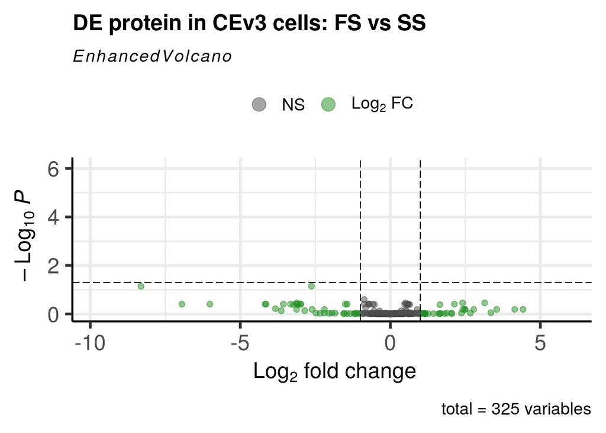

```r
# limma results direct
output_dir_res <- paste0(Data,"Output/MIB-BL/DEP_Bl_Par/","Limma_res/")

# Import comps of interest
coi <- read.csv(paste0(output_dir_res, "comp_9_CEv3.full-CEv3.starve.csv") , row.names = 1)

# Title
VolTitle <- "DE protein in CEv3 cells: FS vs SS"

# Plot Volcano
volcano_plot <-
    EnhancedVolcano(
      coi,
      lab=row.names(coi),
      x="logFC",
      y="adj.P.Val",
      title= paste0(VolTitle),
      pCutoff =0.05,
      #FCcutoff =lfc,
      pointSize = 2.0,
      labSize = 5.0
    )

volcano_plot
```

```r
# Save Volcano
ggsave(filename = paste0(figures_dir,VolTitle,".pdf"), plot=volcano_plot)
```

## C_Protein

### Fig.1H

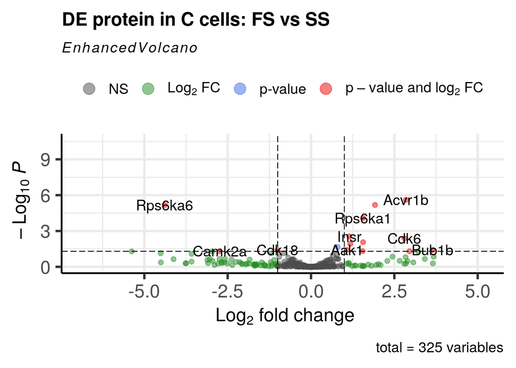

```r
# limma results direct
output_dir_res <- paste0(Data,"Output/MIB-BL/DEP_Bl_Par/","Limma_res/")

# Import comps of interest
coi <- read.csv(paste0(output_dir_res, "comp_1_C.full-C.starve.csv") , row.names = 1)

# Title
VolTitle <- "DE protein in C cells: FS vs SS"

# Plot Volcano
volcano_plot <-
    EnhancedVolcano(
      coi,
      lab=row.names(coi),
      x="logFC",
      y="adj.P.Val",
      title= paste0(VolTitle),
      pCutoff =0.05,
      #FCcutoff =lfc,
      pointSize = 2.0,
      labSize = 5.0
    )

volcano_plot
```

```r
# Save Volcano
ggsave(filename = paste0(figures_dir,VolTitle,".pdf"), plot=volcano_plot)
```

## CEv3_RNA

### S.2C

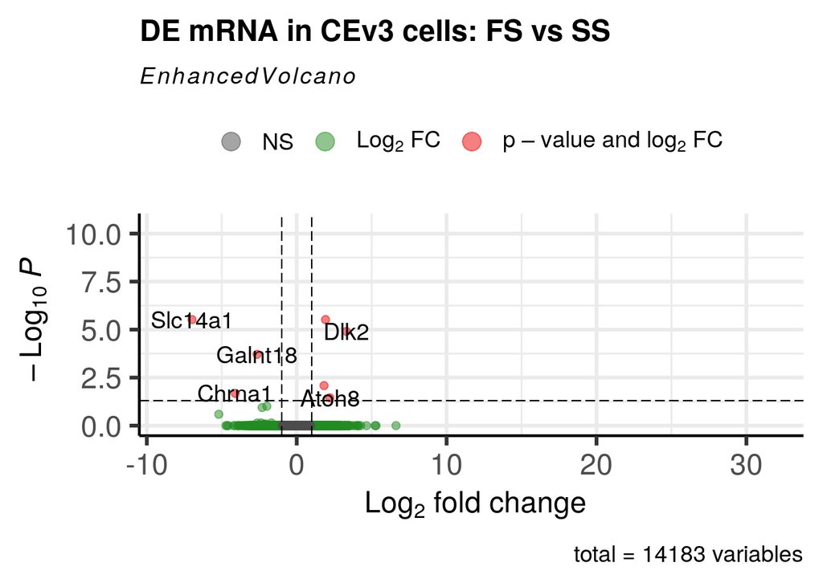

```r
# limma results direct
output_dir_res <- paste0(Data,"Output/RNA/dds_EDA_subset/bl_Par/","DE2_res/")

# Import comps of interest
coi <- read.csv(paste0(output_dir_res, "comp_6_full_CEv3_NA_0-vs-starve_CEv3_NA_0.csv") , row.names = 1)

# Title
VolTitle <- "DE mRNA in CEv3 cells: FS vs SS"

# Plot Volcano
volcano_plot <-
    EnhancedVolcano(
      coi,
      lab=row.names(coi),
      x="log2FoldChange",
      y="padj",
      title= paste0(VolTitle),
      pCutoff =0.05,
      FCcutoff =1,
      pointSize = 2.0,
      labSize = 5.0
    )

volcano_plot
```

```r
# Save Volcano
ggsave(filename = paste0(figures_dir,VolTitle,".pdf"), plot=volcano_plot)
```

## C_RNA

### S.2D

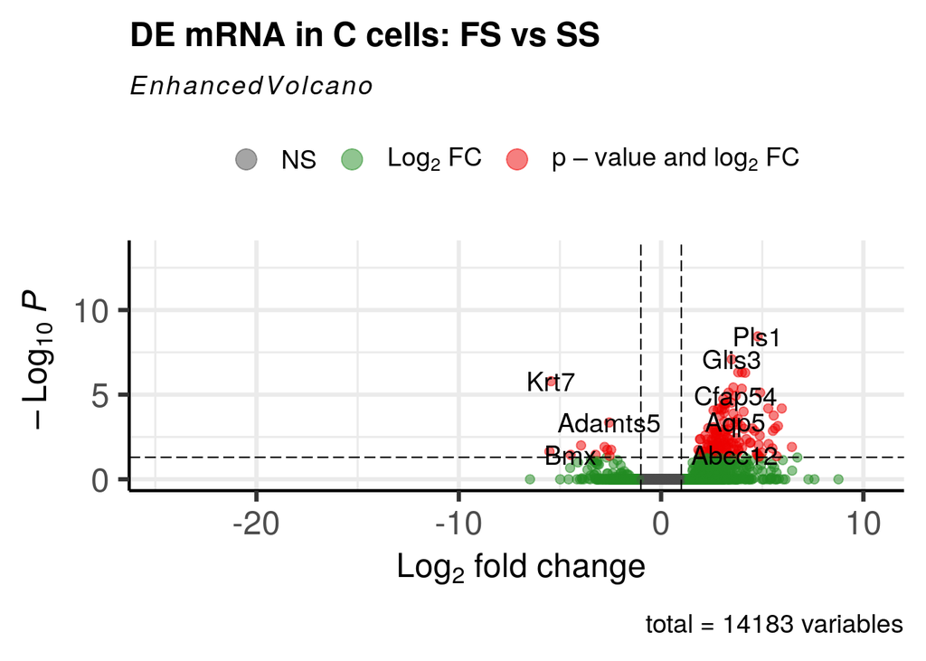

```r
# limma results direct
output_dir_res <- paste0(Data,"Output/RNA/dds_EDA_subset/bl_Par/","DE2_res/")

# Import comps of interest
coi <- read.csv(paste0(output_dir_res, "comp_2_full_C_NA_0-vs-starve_C_NA_0.csv") , row.names = 1)

# Title
VolTitle <- "DE mRNA in C cells: FS vs SS"

# Plot Volcano
volcano_plot <-
    EnhancedVolcano(
      coi,
      lab=row.names(coi),
      x="log2FoldChange",
      y="padj",
      title= paste0(VolTitle),
      pCutoff =0.05,
      FCcutoff =1,
      pointSize = 2.0,
      labSize = 5.0
    )

volcano_plot
```

```r
# Save Volcano
ggsave(filename = paste0(figures_dir,VolTitle,".pdf"), plot=volcano_plot)
```

# EGFR_TKI_Resistance_sig

EGFR TKI resistance signature (in vitro models)

Setup

```r
# Clean environment
rm(list = ls())
gc()
```

```
##            used  (Mb) gc trigger   (Mb) max used   (Mb)
## Ncells 15655377 836.1   25160558 1343.8 25160558 1343.8
## Vcells 27444973 209.4   47131234  359.6 39627956  302.4
```

```r
# Import setup workspace
load(paste0("/Data/Input/Figures/setup_workspace.RData"))
```

Directories

```r
fig.label <- paste0("EGFR_TKI_Resistance_sig")
input_dir <- paste0(Data,"Input/Figures/",fig.label,"/")
output_dir <- paste0(Data,"Figures/",fig.label,"/")
dir.create(output_dir)
```

## mRNA_Full

Import SE and vst transformation

```r
# Import SE object of samples
dds_Bl_Res_fs <- readRDS(tail(grep("bl_Res_fs.rds",list.files(paste0(Data,"Output/RNA/dds_EDA_subset/bl_Res_fs"), recursive = T, full.names = T), value = T),1))

# vst transformation
vsd<-vst(dds_Bl_Res_fs, blind=T, nsub=1000, fitType = "parametric")
```

Import genesets

```r
# Import GOI for heatmap
Heatmap_GOI_df <- read.csv(paste0(input_dir,"Heatmap_GOI.csv"))

# Convert heatmap GOI to mouse
convert_human2mouse <-merge(bm_hEGFR,Heatmap_GOI_df, by.x="hsapiens_homolog_associated_gene_name", by.y="WP_EGFR_TYROSINE_KINASE_INHIBITOR_RESISTANCE")

# Extract mouse genes
Heatmap_GOI_df <- data.frame(convert_human2mouse[,"external_gene_name"])

# Rename columns
colnames(Heatmap_GOI_df) <- c("gene_symbol")
```

Make Heatmap ### Fig.2E

```r
# Subset vsd to genes in GOI
vsd_Heatmap_GOI <- vsd[row.names(vsd) %in% Heatmap_GOI_df$gene_symbol,]

# Filter for top 25 variable genes
#vsd_Heatmap_GOI <-  vsd_Heatmap_GOI[head(order(rowVars(as.matrix(assay(vsd_Heatmap_GOI))),decreasing=T), 25), ]

# Extract matrix values from vsd_Heatmap_GOI
mat <- as.matrix(assay(vsd_Heatmap_GOI))

# Heatmap annotations
annotation_col <- HeatmapAnnotation(df = data.frame("Model" = factor(vsd_Heatmap_GOI@colData$cell_line_abbr,
                                                    # Set legend order
                                                    levels= c("CEv3","E4","E5","G1","G5","G8","G12")),
                                                    "Sen" = vsd_Heatmap_GOI@colData$EGFR_TKI_sen),
    which="column",
    col = list("Model" =
  c(
    'CEv3' = 'red',
    'E4' = 'deepskyblue4',
    'E5' = 'turquoise3',
    'G1' = 'purple4',
    'G5' = 'mediumorchid',
    'G8' = 'deeppink',
    'G12' = 'pink2'
  ),
  Sen =
    c('Resistant'='brown',
      'Sensitive'='blue')
  ))

# Generate Heatmap
heatmap <- ComplexHeatmap::Heatmap(
  t(scale(t(mat))),
  top_annotation = annotation_col,
  name = " ",
  column_title = "FS_WP_EGFR_TYROSINE_KINASE_INHIBITOR_RESISTANCE",
  show_column_names = F,
  show_row_names = F
  )

# Save Heatmap
pdf(file=paste0(output_dir,"FS_WP_EGFR_TKI_Res.pdf"))
draw(heatmap)
dev.off()
```

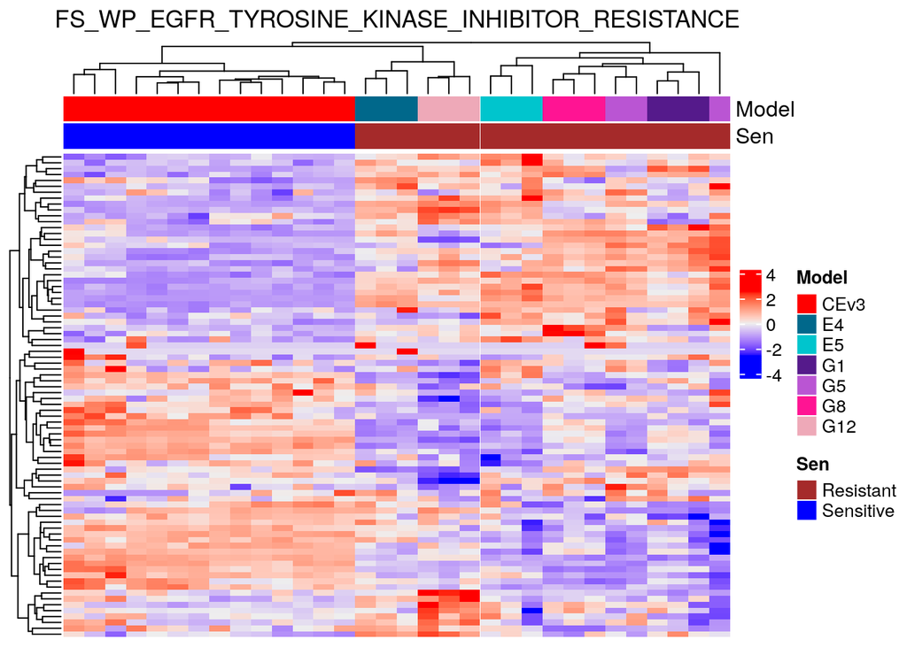

```r
# Draw Heatmap
draw(heatmap)
```

```r
# Graphics termination
if(!is.null(dev.list())) dev.off()
```

```r
if(!is.null(dev.list())) graphics.off()
```

## mRNA_Starve

Import SE and vst transformation

```r
# Import SE object of samples
dds_Bl_Res_ss <- readRDS(tail(grep("bl_Res_ss.rds",list.files(paste0(Data,"Output/RNA/dds_EDA_subset/bl_Res_ss"), recursive = T, full.names = T), value = T),1))

# vst transformation
vsd<-vst(dds_Bl_Res_ss, blind=T, nsub=1000, fitType = "parametric")
```

Import genesets

```r
# Import GOI for heatmap
Heatmap_GOI_df <- read.csv(paste0(input_dir,"Heatmap_GOI.csv"))

# Convert heatmap GOI to mouse
convert_human2mouse <-merge(bm_hEGFR,Heatmap_GOI_df, by.x="hsapiens_homolog_associated_gene_name", by.y="WP_EGFR_TYROSINE_KINASE_INHIBITOR_RESISTANCE")

# Extract mouse genes
Heatmap_GOI_df <- data.frame(convert_human2mouse[,"external_gene_name"])

# Rename columns
colnames(Heatmap_GOI_df) <- c("gene_symbol")
```

Make Heatmap ### Fig.2F

```r
# Subset vsd to genes in GOI
vsd_Heatmap_GOI <- vsd[row.names(vsd) %in% Heatmap_GOI_df$gene_symbol,]

# Filter for top 25 variable genes
# vsd_Heatmap_GOI <-  vsd_Heatmap_GOI[head(order(rowVars(as.matrix(assay(vsd_Heatmap_GOI))),decreasing=T), 25), ]

# Extract matrix values from vsd_Heatmap_GOI
mat <- as.matrix(assay(vsd_Heatmap_GOI))

# Heatmap annotations
annotation_col <- HeatmapAnnotation(df = data.frame("Model" = factor(vsd_Heatmap_GOI@colData$cell_line_abbr,
                                                    # Set legend order
                                                    levels= c("CEv3","E4","E5","G1","G5","G8","G12")),
                                                    "Sen" = vsd_Heatmap_GOI@colData$EGFR_TKI_sen),
    which="column",
    col = list("Model" =
  c(
    'CEv3' = 'red',
    'E4' = 'deepskyblue4',
    'E5' = 'turquoise3',
    'G1' = 'purple4',
    'G5' = 'mediumorchid',
    'G8' = 'deeppink',
    'G12' = 'pink2'
  ),
  Sen =
    c('Resistant'='brown',
      'Sensitive'='blue')
  ))

# Generate Heatmap
heatmap <- ComplexHeatmap::Heatmap(
  t(scale(t(mat))),
  top_annotation = annotation_col,
  name = " ",
  column_title = "SS_WP_EGFR_TYROSINE_KINASE_INHIBITOR_RESISTANCE",
  show_column_names = F,
  show_row_names = F
  )

# Save Heatmap
pdf(file=paste0(output_dir,"SS_WP_EGFR_TKI_Res.pdf"))
draw(heatmap)
dev.off()
```

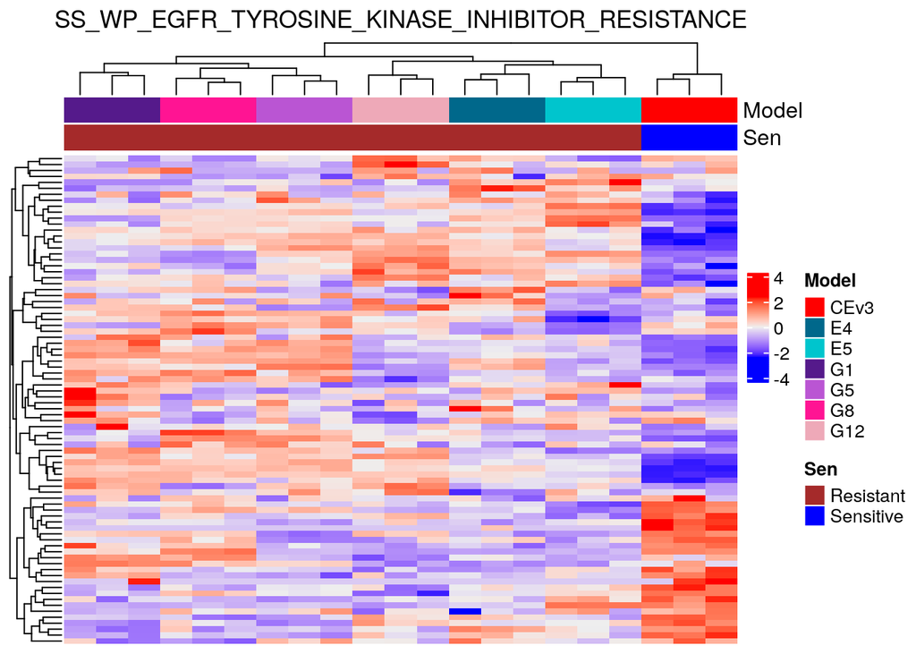

```r
# Draw Heatmap
draw(heatmap)
```

```r
# Graphics termination
if(!is.null(dev.list())) dev.off()
```

```r
if(!is.null(dev.list())) graphics.off()
```

## protein_full

Import SE and vst transformation

```r
# Import Protein vsd
DEP_Bl_Res_fs <- readRDS(tail(grep("DEP_Bl_Res_fs.rds",list.files(paste0(Data,"Output/MIB-BL/DEP_Bl_Res_fs"), recursive = T, full.names = T), value = T),1))
DEP_Bl_Res_ss <- readRDS(tail(grep("DEP_Bl_Res_ss.rds",list.files(paste0(Data,"Output/MIB-BL/DEP_Bl_Res_ss"), recursive = T, full.names = T), value = T),1))

# vst transformation
vsd<- DEP_Bl_Res_fs
```

Import genesets

```r
# Import GOI for heatmap
Heatmap_GOI_df <- read.csv(paste0(input_dir,"Heatmap_GOI.csv"))

# Convert heatmap GOI to mouse
convert_human2mouse <-merge(bm_hEGFR,Heatmap_GOI_df, by.x="hsapiens_homolog_associated_gene_name", by.y="WP_EGFR_TYROSINE_KINASE_INHIBITOR_RESISTANCE")

# Extract mouse genes
Heatmap_GOI_df <- data.frame(convert_human2mouse[,"external_gene_name"])

# Rename columns
colnames(Heatmap_GOI_df) <- c("gene_symbol")
```

Make Heatmap ### Fig.2G

```r
# Subset vsd to genes in GOI
vsd_Heatmap_GOI <- vsd[row.names(vsd) %in% Heatmap_GOI_df$gene_symbol,]

# Filter for top 25 variable genes
#vsd_Heatmap_GOI <-  vsd_Heatmap_GOI[head(order(rowVars(as.matrix(assay(vsd_Heatmap_GOI))),decreasing=T), 25), ]

# Extract matrix values from vsd_Heatmap_GOI
mat <- as.matrix(assay(vsd_Heatmap_GOI))

# Heatmap annotations
annotation_col <- HeatmapAnnotation(df = data.frame("Model" = factor(vsd_Heatmap_GOI@colData$cell_line_abbr,
                                                    # Set legend order
                                                    levels= c("CEv3","E4","E5","G1","G5","G8","G12")),
                                                    "Sen" = vsd_Heatmap_GOI@colData$EGFR_TKI_sen),
    which="column",
    col = list("Model" =
  c(
    'CEv3' = 'red',
    'E4' = 'deepskyblue4',
    'E5' = 'turquoise3',
    'G1' = 'purple4',
    'G5' = 'mediumorchid',
    'G8' = 'deeppink',
    'G12' = 'pink2'
  ),
  Sen =
    c('Resistant'='brown',
      'Sensitive'='blue')
  ))

# Generate Heatmap
heatmap <- ComplexHeatmap::Heatmap(
  t(scale(t(mat))),
  top_annotation = annotation_col,
  name = " ",
  column_title = "Protein_FS_WP_EGFR_TYROSINE_KINASE_INHIBITOR_RESISTANCE",
  show_column_names = F,
  show_row_names = T
  )

# Save Heatmap
pdf(file=paste0(output_dir,"Protein_FS_WP_EGFR_TKI_Res.pdf"))
draw(heatmap)
dev.off()
```

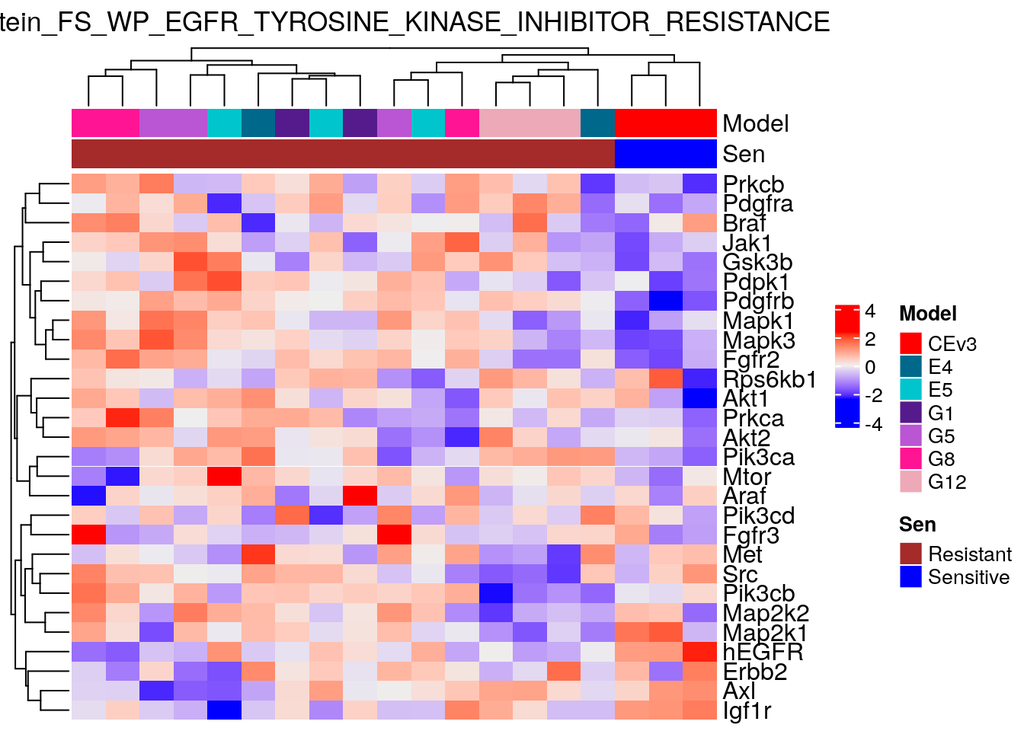

```r
# Draw Heatmap
draw(heatmap)
```

```r
# Graphics termination
if(!is.null(dev.list())) dev.off()
```

```r
if(!is.null(dev.list())) graphics.off()
```

## protein_starve

Import SE and vst transformation

```r
# Import Protein vsd
DEP_Bl_Res_fs <- readRDS(tail(grep("DEP_Bl_Res_fs.rds",list.files(paste0(Data,"Output/MIB-BL/DEP_Bl_Res_fs"), recursive = T, full.names = T), value = T),1))
DEP_Bl_Res_ss <- readRDS(tail(grep("DEP_Bl_Res_ss.rds",list.files(paste0(Data,"Output/MIB-BL/DEP_Bl_Res_ss"), recursive = T, full.names = T), value = T),1))

# vst transformation
vsd<- DEP_Bl_Res_ss
```

Import genesets

```r
# Import GOI for heatmap
Heatmap_GOI_df <- read.csv(paste0(input_dir,"Heatmap_GOI.csv"))

# Convert heatmap GOI to mouse
convert_human2mouse <-merge(bm_hEGFR,Heatmap_GOI_df, by.x="hsapiens_homolog_associated_gene_name", by.y="WP_EGFR_TYROSINE_KINASE_INHIBITOR_RESISTANCE")

# Extract mouse genes
Heatmap_GOI_df <- data.frame(convert_human2mouse[,"external_gene_name"])

# Rename columns
colnames(Heatmap_GOI_df) <- c("gene_symbol")
```

Make Heatmap ### Fig.2H

```r
# Subset vsd to genes in GOI
vsd_Heatmap_GOI <- vsd[row.names(vsd) %in% Heatmap_GOI_df$gene_symbol,]

# Filter for top 25 variable genes
#vsd_Heatmap_GOI <-  vsd_Heatmap_GOI[head(order(rowVars(as.matrix(assay(vsd_Heatmap_GOI))),decreasing=T), 25), ]

# Extract matrix values from vsd_Heatmap_GOI
mat <- as.matrix(assay(vsd_Heatmap_GOI))

# Heatmap annotations
annotation_col <- HeatmapAnnotation(df = data.frame("Model" = factor(vsd_Heatmap_GOI@colData$cell_line_abbr,
                                                    # Set legend order
                                                    levels= c("CEv3","E4","E5","G1","G5","G8","G12")),
                                                    "Sen" = vsd_Heatmap_GOI@colData$EGFR_TKI_sen),
    which="column",
    col = list("Model" =
  c(
    'CEv3' = 'red',
    'E4' = 'deepskyblue4',
    'E5' = 'turquoise3',
    'G1' = 'purple4',
    'G5' = 'mediumorchid',
    'G8' = 'deeppink',
    'G12' = 'pink2'
  ),
  Sen =
    c('Resistant'='brown',
      'Sensitive'='blue')
  ))

# Generate Heatmap
heatmap <- ComplexHeatmap::Heatmap(
  t(scale(t(mat))),
  top_annotation = annotation_col,
  name = " ",
  column_title = "Protein_SS_WP_EGFR_TYROSINE_KINASE_INHIBITOR_RESISTANCE",
  show_column_names = F,
  show_row_names = T
  )

# Save Heatmap
pdf(file=paste0(output_dir,"Protein_SS_WP_EGFR_TKI_Res.pdf"))
draw(heatmap)
dev.off()
```

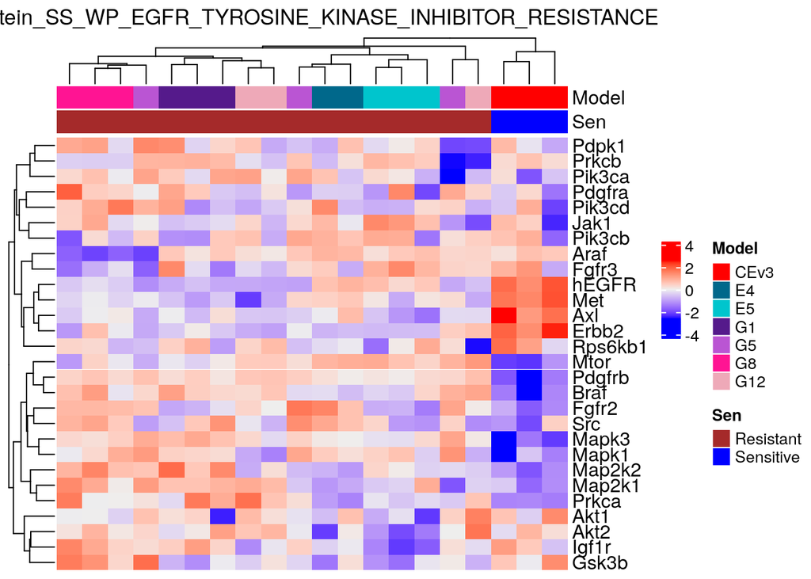

```r
# Draw Heatmap
draw(heatmap)
```

```r
# Graphics termination
if(!is.null(dev.list())) dev.off()
```

```r
if(!is.null(dev.list())) graphics.off()
```

# Resistance cell lines volcano plots

Directories

```r
fig.label <- paste0("Res_signature_volcanos")
figures_dir <- paste0(Data,"Figures/",fig.label,"/")
dir.create(figures_dir)
```

## fs

### Import Limma Res fs

#### S.4A-F

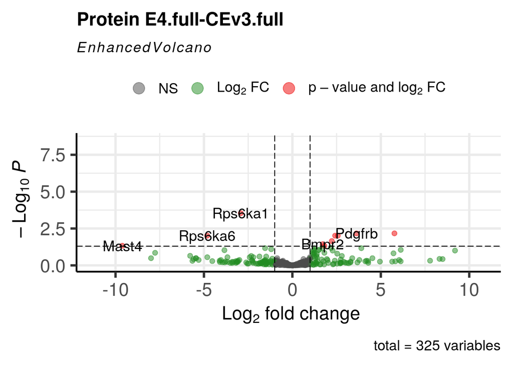

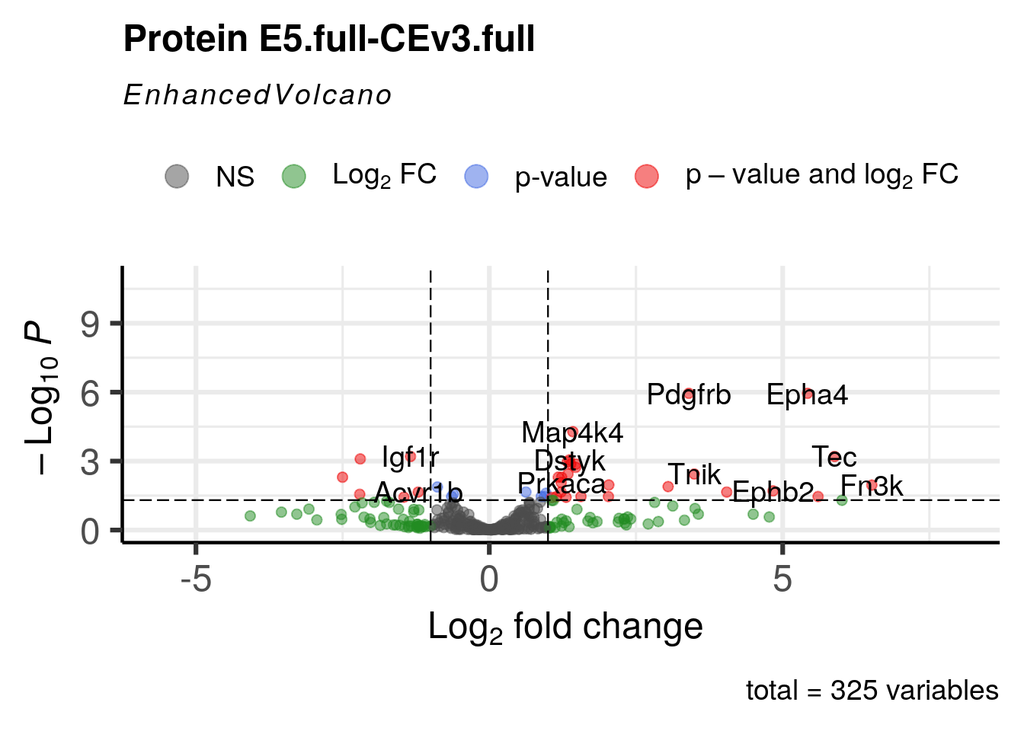

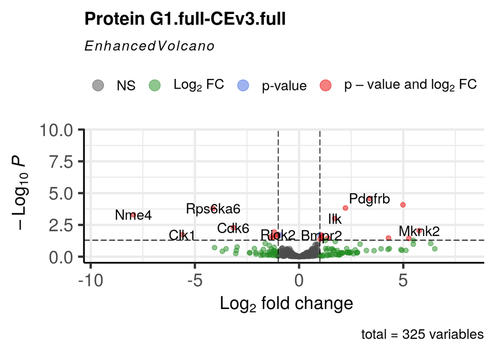

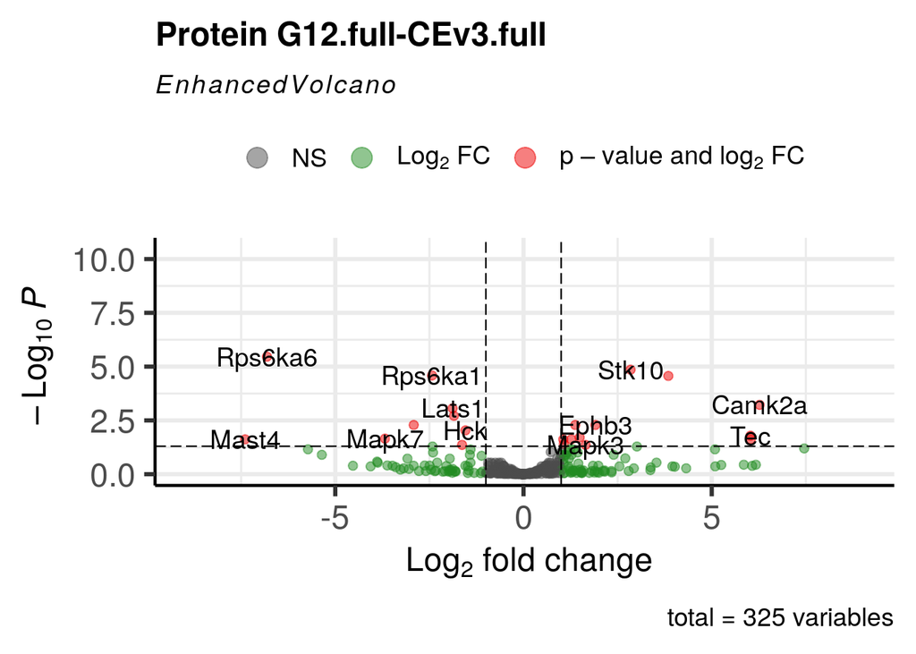

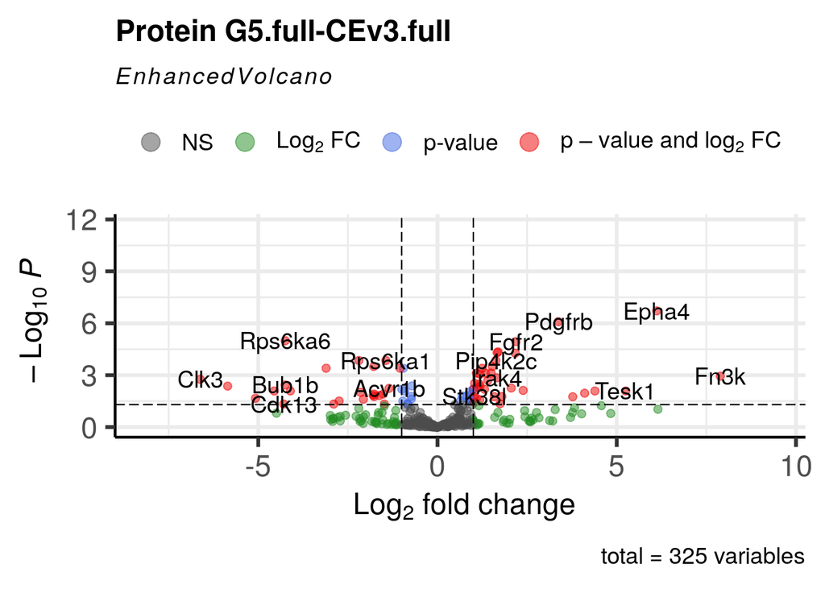

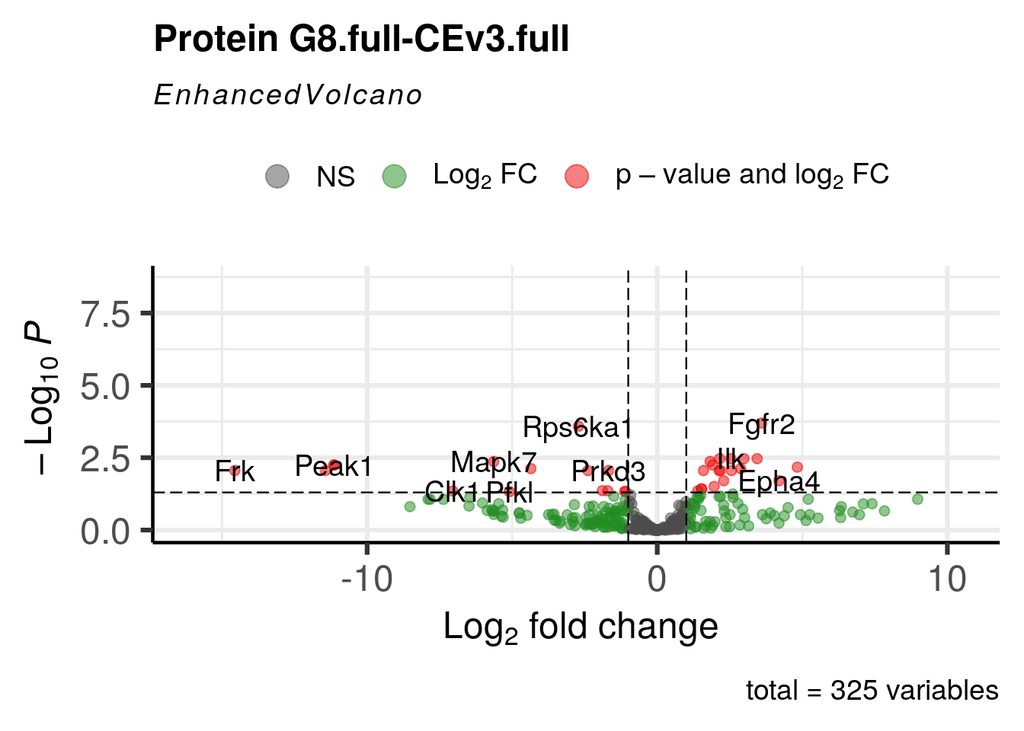

```r
fig.label <- paste0("Res_signature_volcanos")
figures_dir <- paste0(Data,"Figures/",fig.label,"/")
dir.create(figures_dir)
# limma results direct
output_dir_res <- paste0(Data,"Output/MIB-BL/DEP_Bl_Res_fs/","Limma_res/")

# Summarize of comparisions
comps <- read.csv(paste0(Data,"Output/MIB-BL/DEP_Bl_Res_fs/","comps_all.csv"), row.names = 1)

# import limma res
subset_limmaRes <- list()
for (i in seq_along(row.names(comps))){
  subset_limmaRes[[comps$comp[i]]] <-
  read.csv(paste0(output_dir_res,"comp_",i,"_",comps[i,5],".csv"), row.names = 1)
}

# Extract comps of interest
coi <- comps[comps$comp_denom %in% c("CEv3.full"),]$comp
comp_list_oi <- subset_limmaRes[names(subset_limmaRes) %in% coi]


# Plot Volcano
volcano_plots_ls <- list()
for (i in seq_along(comp_list_oi)){
  plot(volcano_plots_ls[[names(comp_list_oi)[i]]] <-
    EnhancedVolcano(
      comp_list_oi[[i]],
      lab=row.names(comp_list_oi[[i]]),
      x="logFC",
      y="adj.P.Val",
      title= paste0("Protein ",names(comp_list_oi)[[i]]),
      pCutoff =0.05,
      #FCcutoff =lfc,
      pointSize = 2.0,
      labSize = 5.0
    ))}
```

```r
# Save Volcano
for (i in seq_along(volcano_plots_ls)){
ggsave(filename = paste0(figures_dir,"comp_", i, "_", names(volcano_plots_ls)[[i]],".pdf"), plot=volcano_plots_ls[[i]])
}
```

## ss

### Import Limma Res ss

#### S.5A-F

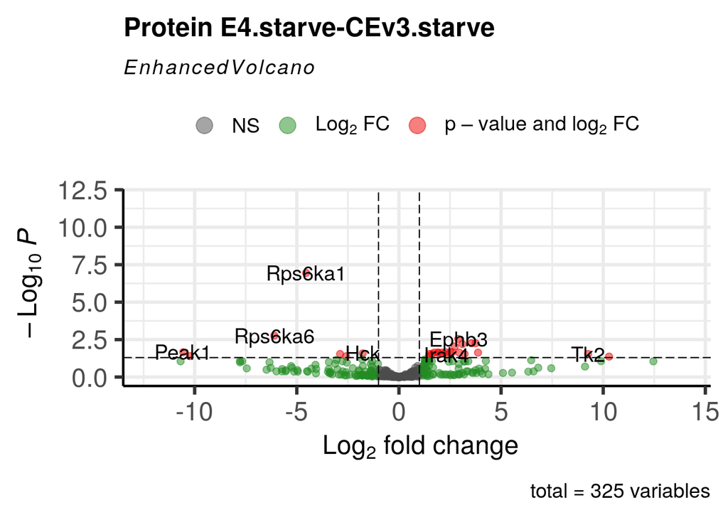

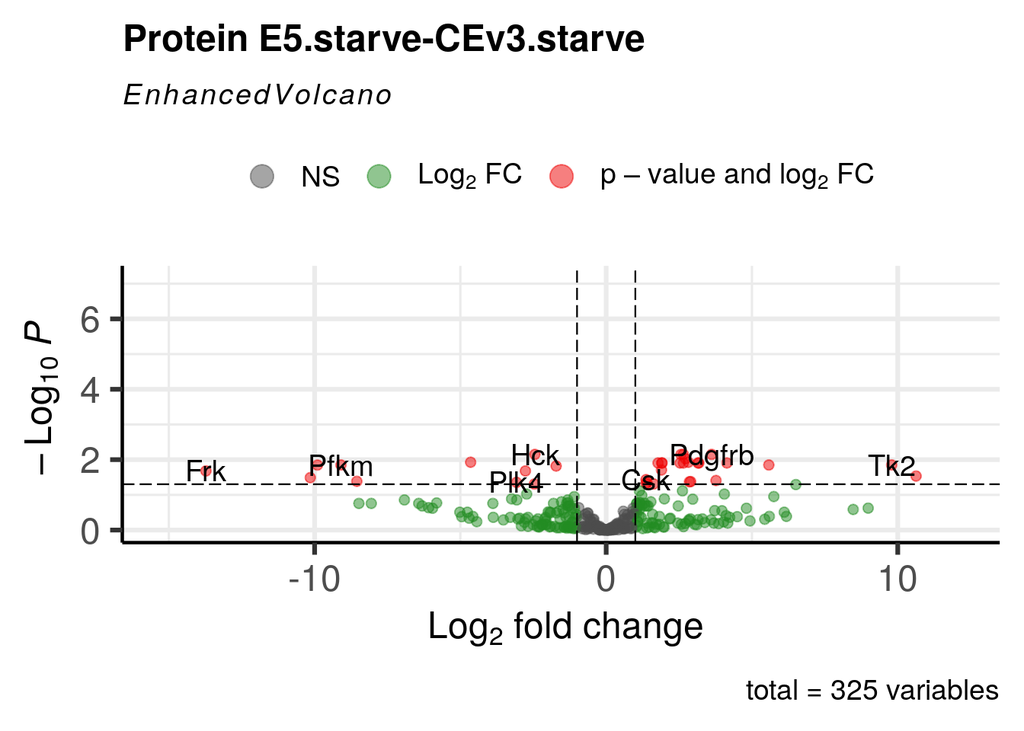

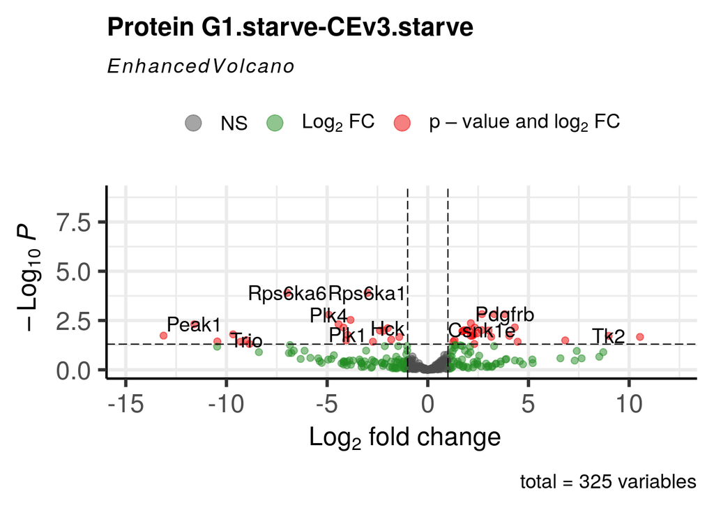

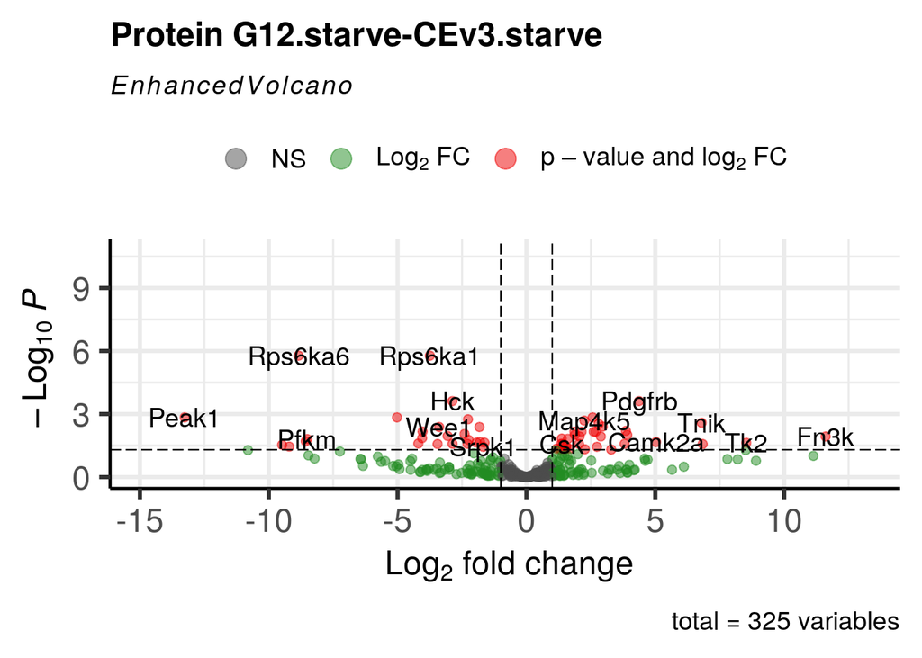

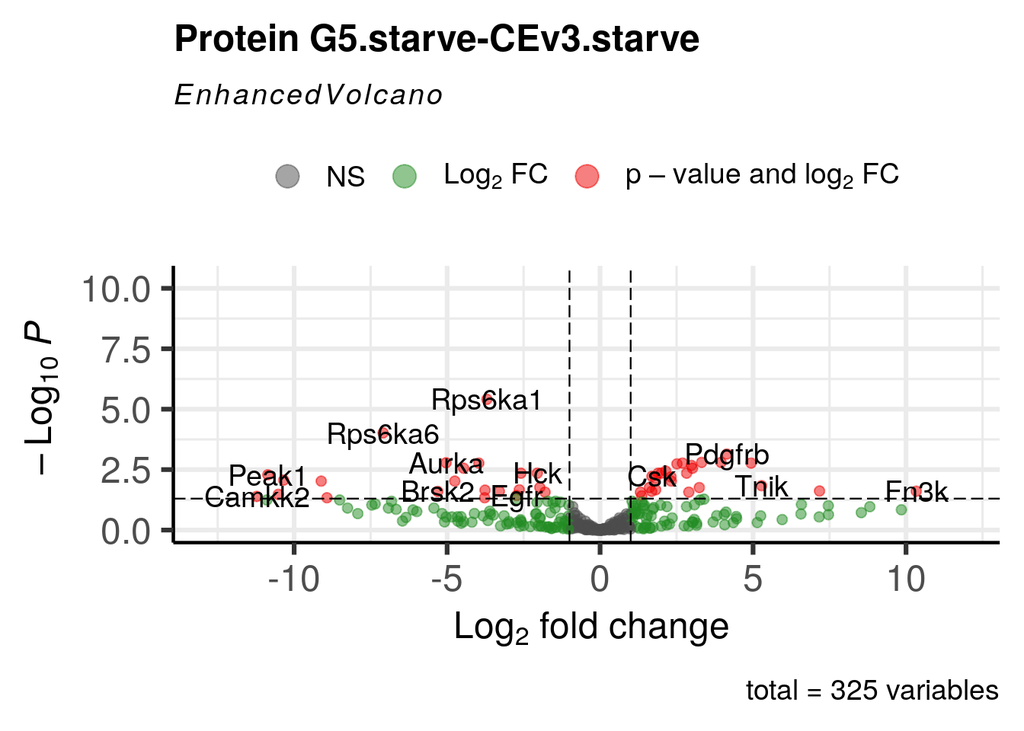

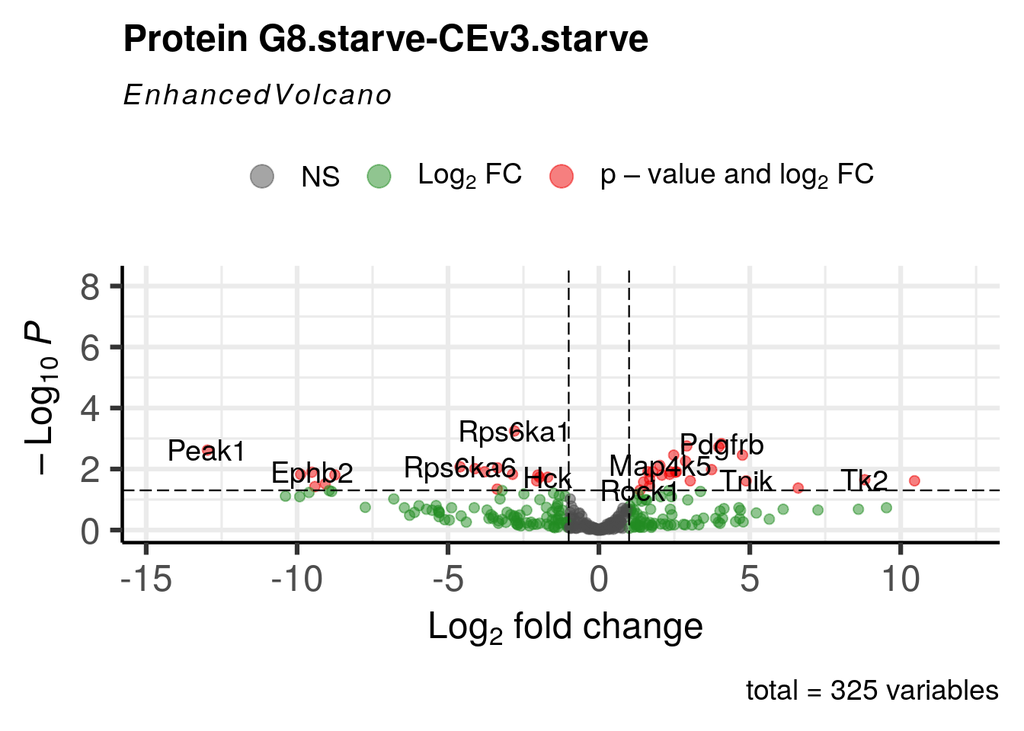

```r
# limma results direct
output_dir_res <- paste0(Data,"Output/MIB-BL/DEP_Bl_Res_ss/","Limma_res/")

# Summarize of comparisions
comps <- read.csv(paste0(Data,"Output/MIB-BL/DEP_Bl_Res_ss/","comps_all.csv"), row.names = 1)

# import limma res
subset_limmaRes <- list()
for (i in seq_along(row.names(comps))){
  subset_limmaRes[[comps$comp[i]]] <-
  read.csv(paste0(output_dir_res,"comp_",i,"_",comps[i,5],".csv"), row.names = 1)
}

# Extract comps of interest
coi <- comps[comps$comp_denom %in% c("CEv3.starve"),]$comp
comp_list_oi <- subset_limmaRes[names(subset_limmaRes) %in% coi]


# Plot Volcano
volcano_plots_ls <- list()
for (i in seq_along(comp_list_oi)){
  plot(volcano_plots_ls[[names(comp_list_oi)[i]]] <-
    EnhancedVolcano(
      comp_list_oi[[i]],
      lab=row.names(comp_list_oi[[i]]),
      x="logFC",
      y="adj.P.Val",
      title= paste0("Protein ",names(comp_list_oi)[[i]]),
      pCutoff =0.05,
      #FCcutoff =lfc,
      pointSize = 2.0,
      labSize = 5.0
    ))}
```

```r
# Save Volcano
for (i in seq_along(volcano_plots_ls)){
ggsave(filename = paste0(figures_dir,"comp_", i, "_", names(volcano_plots_ls)[[i]],".pdf"), plot=volcano_plots_ls[[i]])
}
```

# Baseline_kinase_upset

Setup

```r
# Clean environment
rm(list = ls())
gc()
```

```
##            used  (Mb) gc trigger   (Mb) max used   (Mb)
## Ncells 15643339 835.5   25160558 1343.8 25160558 1343.8
## Vcells 27330010 208.6   47131234  359.6 42568578  324.8
```

```r
# Import setup workspace
load(paste0("/Data/Input/Figures/setup_workspace.RData"))
```

Directories

```r
fig.label <- paste0("Baseline_kinase_upset")
input_dir <- paste0(Data,"Input/Figures/",fig.label,"/")
figures_dir <- paste0(Data,"Figures/",fig.label,"/")
dir.create(figures_dir)
```

Import Limma Res fs

```r
DEP_Bl_Res_fs_limma_res_padj <- read.csv(paste0(Data,"/Output/MIB-BL/DEP_Bl_Res_fs/Limma_res/","All_coi_padj.csv"), row.names = 1)

# Extract significant genes
E4_sig_genes <- row.names(subset(DEP_Bl_Res_fs_limma_res_padj, DEP_Bl_Res_fs_limma_res_padj$adj.P.Val_E4.full.CEv3.full<0.05))
E5_sig_genes <- row.names(subset(DEP_Bl_Res_fs_limma_res_padj, DEP_Bl_Res_fs_limma_res_padj$adj.P.Val_E5.full.CEv3.full<0.05))
G1_sig_genes <- row.names(subset(DEP_Bl_Res_fs_limma_res_padj, DEP_Bl_Res_fs_limma_res_padj$adj.P.Val_G1.full.CEv3.full<0.05))
G5_sig_genes <- row.names(subset(DEP_Bl_Res_fs_limma_res_padj, DEP_Bl_Res_fs_limma_res_padj$adj.P.Val_G5.full.CEv3.full<0.05))
G8_sig_genes <- row.names(subset(DEP_Bl_Res_fs_limma_res_padj, DEP_Bl_Res_fs_limma_res_padj$adj.P.Val_G8.full.CEv3.full<0.05))
G12_sig_genes <- row.names(subset(DEP_Bl_Res_fs_limma_res_padj, DEP_Bl_Res_fs_limma_res_padj$adj.P.Val_G12.full.CEv3.full<0.05))

# Convert to list
DEP_Bl_Res_fs_sigGenes_ls <- list(
  E4_fs=E4_sig_genes,
  E5_fs=E5_sig_genes,
  G1_fs=G1_sig_genes,
  G5_fs=G5_sig_genes,
  G8_fs=G8_sig_genes,
  G12_fs=G12_sig_genes
)

# Remove hEGFR
DEP_Bl_Res_fs_sigGenes_ls <- lapply(DEP_Bl_Res_fs_sigGenes_ls, function(x) subset(x,!x=="hEGFR"))
```

## Upset Plot fs

### Fig.3A

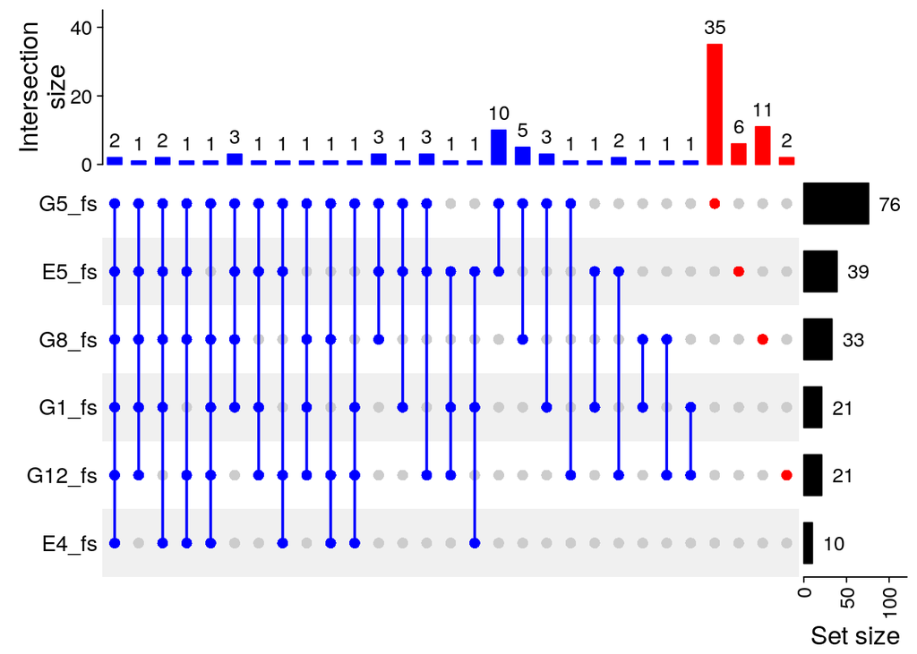

```r
# Directories
output_dir_upset <- paste0(figures_dir)
graph_dir_upset <- paste0(figures_dir)


# Convert list to binary matrix
Upset_matrix <- ComplexHeatmap::list_to_matrix(DEP_Bl_Res_fs_sigGenes_ls)

# Save Upset_matrix
write.csv(Upset_matrix, file = paste0(output_dir_upset, "baseline_FS_upset_matrix",".csv"))

# convert list to combination matrix
combo_matrix <- ComplexHeatmap::make_comb_mat(Upset_matrix)

# Color by intersection
intersection_degree <- comb_degree(combo_matrix)
comb_col <- ifelse(intersection_degree > 1, "blue", "red")


# Generate upset plot
upset_plot <- ComplexHeatmap::UpSet(combo_matrix, comb_col = comb_col,
                        row_names_gp =gpar(fontsize = 12) ,
                        top_annotation = upset_top_annotation(
                          combo_matrix,
                          add_numbers = TRUE,
                          numbers_gp = gpar(fontsize = 11),
                          numbers_rot=0,
                          annotation_name_rot = 90,
                          axis_param=list (gp = gpar(fontsize = 11)),
                          annotation_name_gp= gpar(fontsize = 14)),
                        right_annotation = upset_right_annotation(
                          combo_matrix,
                          add_numbers = TRUE,
                          numbers_gp = gpar(fontsize = 11),
                          numbers_rot=0,
                          axis_param=list (gp = gpar(fontsize = 11)),
                          annotation_name_gp= gpar(fontsize = 14)),
                        pt_size = unit(8, "pt"))

upset_plot
```

```r
# Save upset_plot
pdf(file=paste0(graph_dir_upset, "baseline_FS_upset" , ".pdf"))
draw(upset_plot)
dev.off()
```

```r
# Combination matrix
combo_matrix
```

```
## A combination matrix with 6 sets and 29 combinations.
##   ranges of combination set size: c(1, 35).
##   mode for the combination size: distinct.
##   sets are on rows.
##
## Top 8 combination sets are:
##   E4_fs E5_fs G1_fs G5_fs G8_fs G12_fs   code size
##                         x              000100   35
##                               x        000010   11
##             x           x              010100   10
##             x                          010000    6
##                         x     x        000110    5
##             x     x     x     x        011110    3
##             x           x     x        010110    3
##             x           x            x 010101    3
##
## Sets are:
##      set size
##    E4_fs   10
##    E5_fs   39
##    G1_fs   21
##    G5_fs   76
##    G8_fs   33
##   G12_fs   21
```

```r
comb_name(combo_matrix)
```

```
##  [1] "111111" "111110" "110111" "101111" "011111" "110101" "101101" "100111"
##  [9] "011110" "011101" "001111" "111000" "011100" "011001" "010110" "010101"
## [17] "011000" "010100" "010001" "001100" "001010" "001001" "000110" "000101"
## [25] "000011" "010000" "000100" "000010" "000001"
```

```r
# Extract all from upset plot
upset_genes_ls <- list()
for(i in seq_along(comb_name(combo_matrix))){
  upset_genes_ls[[paste0((set_name(combo_matrix)["1"==strsplit(comb_name(combo_matrix)[i],"")[[1]]])[1],"_",(set_name(combo_matrix)["1"==strsplit(comb_name(combo_matrix)[i],"")[[1]]])[2],"_",(set_name(combo_matrix)["1"==strsplit(comb_name(combo_matrix)[i],"")[[1]]])[3],"_",(set_name(combo_matrix)["1"==strsplit(comb_name(combo_matrix)[i],"")[[1]]])[4],"_",(set_name(combo_matrix)["1"==strsplit(comb_name(combo_matrix)[i],"")[[1]]])[5],"_",(set_name(combo_matrix)["1"==strsplit(comb_name(combo_matrix)[i],"")[[1]]])[6])]] <-
    extract_comb(combo_matrix,comb_name(combo_matrix)[i])
}

# Convert to DF
upset_genes_df <- do.call(cbind, lapply(upset_genes_ls, function(x) c(x, rep(NA, max(sapply(upset_genes_ls, length)) - length(x)))))

# Save genes
write.csv(upset_genes_df, file = paste0(output_dir_upset,"baseline_FS_upset_genes_df",".csv"))

# Extract unique genes
grep("NA_NA_NA_NA_NA",colnames(upset_genes_df))
```

```
## [1] 26 27 28 29
```

```r
DEP_Bl_Res_fs_unique_genes <- c()
for(i in (grep("NA_NA_NA_NA_NA",colnames(upset_genes_df)))){
  DEP_Bl_Res_fs_unique_genes<- c(DEP_Bl_Res_fs_unique_genes,upset_genes_df[,i][!is.na( upset_genes_df[,i])])
}

# Subset unique genes DF
DEP_Bl_Res_fs_unique_genes_df <- upset_genes_df[,colnames(upset_genes_df)[grep("NA_NA_NA_NA_NA",colnames(upset_genes_df))]]
colnames(DEP_Bl_Res_fs_unique_genes_df) <- gsub("_NA_NA_NA_NA_NA","",colnames(DEP_Bl_Res_fs_unique_genes_df))

# Convert to list
DEP_Bl_Res_fs_unique_genes_ls <- list()
for (i in seq_along(colnames(DEP_Bl_Res_fs_unique_genes_df))){
  DEP_Bl_Res_fs_unique_genes_ls[[colnames(DEP_Bl_Res_fs_unique_genes_df)[i]]] <-
    c(DEP_Bl_Res_fs_unique_genes_df[,i][!is.na(DEP_Bl_Res_fs_unique_genes_df[,i])])
}


# Extract overlapping genes column names
colnames(upset_genes_df)[(grep("NA_NA_NA_NA_NA",colnames(upset_genes_df), invert = T))]
```

```
##  [1] "E4_fs_E5_fs_G1_fs_G5_fs_G8_fs_G12_fs"
##  [2] "E4_fs_E5_fs_G1_fs_G5_fs_G8_fs_NA"
##  [3] "E4_fs_E5_fs_G5_fs_G8_fs_G12_fs_NA"
##  [4] "E4_fs_G1_fs_G5_fs_G8_fs_G12_fs_NA"
##  [5] "E5_fs_G1_fs_G5_fs_G8_fs_G12_fs_NA"
##  [6] "E4_fs_E5_fs_G5_fs_G12_fs_NA_NA"
##  [7] "E4_fs_G1_fs_G5_fs_G12_fs_NA_NA"
##  [8] "E4_fs_G5_fs_G8_fs_G12_fs_NA_NA"
##  [9] "E5_fs_G1_fs_G5_fs_G8_fs_NA_NA"
## [10] "E5_fs_G1_fs_G5_fs_G12_fs_NA_NA"
## [11] "G1_fs_G5_fs_G8_fs_G12_fs_NA_NA"
## [12] "E4_fs_E5_fs_G1_fs_NA_NA_NA"
## [13] "E5_fs_G1_fs_G5_fs_NA_NA_NA"
## [14] "E5_fs_G1_fs_G12_fs_NA_NA_NA"
## [15] "E5_fs_G5_fs_G8_fs_NA_NA_NA"
## [16] "E5_fs_G5_fs_G12_fs_NA_NA_NA"
## [17] "E5_fs_G1_fs_NA_NA_NA_NA"
## [18] "E5_fs_G5_fs_NA_NA_NA_NA"
## [19] "E5_fs_G12_fs_NA_NA_NA_NA"
## [20] "G1_fs_G5_fs_NA_NA_NA_NA"
## [21] "G1_fs_G8_fs_NA_NA_NA_NA"
## [22] "G1_fs_G12_fs_NA_NA_NA_NA"
## [23] "G5_fs_G8_fs_NA_NA_NA_NA"
## [24] "G5_fs_G12_fs_NA_NA_NA_NA"
## [25] "G8_fs_G12_fs_NA_NA_NA_NA"
```

```r
# Extract overlapping genes
DEP_Bl_Res_fs_ol_genes <- c()
for (i in (colnames(upset_genes_df)[(grep("NA_NA_NA_NA_NA",colnames(upset_genes_df), invert = T))])){
  DEP_Bl_Res_fs_ol_genes <-
    c(DEP_Bl_Res_fs_ol_genes,upset_genes_df[,i][!is.na( upset_genes_df[,i] )])

}
```

Import Limma Res ss

```r
DEP_Bl_Res_ss_limma_res_padj <- read.csv(paste0(Data,"/Output/MIB-BL/DEP_Bl_Res_ss/Limma_res/","All_coi_padj.csv"), row.names = 1)

DEP_Bl_Res_ss_limma_res_lfc <- read.csv(paste0(Data,"/Output/MIB-BL/DEP_Bl_Res_ss/Limma_res/","All_coi_l2fc.csv"), row.names = 1)


# Extract significant genes
E4_sig_genes <- row.names(subset(DEP_Bl_Res_ss_limma_res_padj, DEP_Bl_Res_ss_limma_res_padj$adj.P.Val_E4.starve.CEv3.starve<0.05))
E5_sig_genes <- row.names(subset(DEP_Bl_Res_ss_limma_res_padj, DEP_Bl_Res_ss_limma_res_padj$adj.P.Val_E5.starve.CEv3.starve<0.05))
G1_sig_genes <- row.names(subset(DEP_Bl_Res_ss_limma_res_padj, DEP_Bl_Res_ss_limma_res_padj$adj.P.Val_G1.starve.CEv3.starve<0.05))
G5_sig_genes <- row.names(subset(DEP_Bl_Res_ss_limma_res_padj, DEP_Bl_Res_ss_limma_res_padj$adj.P.Val_G5.starve.CEv3.starve<0.05))
G8_sig_genes <- row.names(subset(DEP_Bl_Res_ss_limma_res_padj, DEP_Bl_Res_ss_limma_res_padj$adj.P.Val_G8.starve.CEv3.starve<0.05))
G12_sig_genes <- row.names(subset(DEP_Bl_Res_ss_limma_res_padj, DEP_Bl_Res_ss_limma_res_padj$adj.P.Val_G12.starve.CEv3.starve<0.05))


# Convert to list
DEP_Bl_Res_ss_sigGenes_ls <- list(
  E4_ss=E4_sig_genes,
  E5_ss=E5_sig_genes,
  G1_ss=G1_sig_genes,
  G5_ss=G5_sig_genes,
  G8_ss=G8_sig_genes,
  G12_ss=G12_sig_genes
)

# Remove hEGFR
DEP_Bl_Res_ss_sigGenes_ls <- lapply(DEP_Bl_Res_ss_sigGenes_ls, function(x) subset(x,!x=="hEGFR"))
```

## Upset Plot ss

### Fig.3B

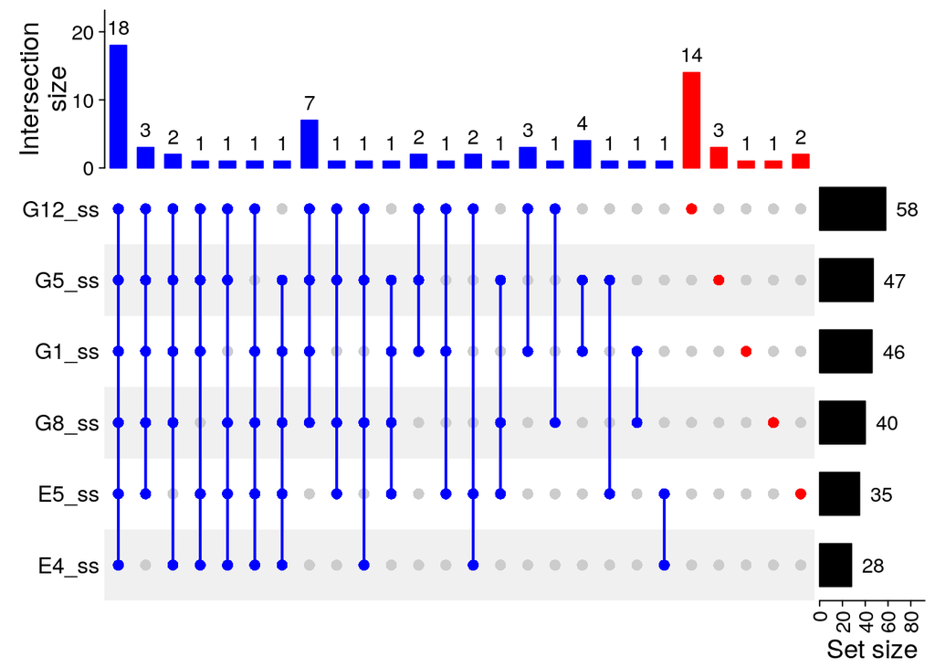

```r
# Directories
output_dir_upset <- paste0(figures_dir)
graph_dir_upset <- paste0(figures_dir)


# Convert list to binary matrix
Upset_matrix <- ComplexHeatmap::list_to_matrix(DEP_Bl_Res_ss_sigGenes_ls)

# Save Upset_matrix
write.csv(Upset_matrix, file = paste0(output_dir_upset, "baseline_ss_upset_matrix",".csv"))

# convert list to combination matrix
combo_matrix <- ComplexHeatmap::make_comb_mat(Upset_matrix)

# Color by intersection
intersection_degree <- comb_degree(combo_matrix)
comb_col <- ifelse(intersection_degree > 1, "blue", "red")


# Generate upset plot
upset_plot <- ComplexHeatmap::UpSet(combo_matrix, comb_col = comb_col,
                        row_names_gp =gpar(fontsize = 12) ,
                        top_annotation = upset_top_annotation(
                          combo_matrix,
                          add_numbers = TRUE,
                          numbers_gp = gpar(fontsize = 11),
                          numbers_rot=0,
                          annotation_name_rot = 90,
                          axis_param=list (gp = gpar(fontsize = 11)),
                          annotation_name_gp= gpar(fontsize = 14)),
                        right_annotation = upset_right_annotation(
                          combo_matrix,
                          add_numbers = TRUE,
                          numbers_gp = gpar(fontsize = 11),
                          numbers_rot=0,
                          axis_param=list (gp = gpar(fontsize = 11)),
                          annotation_name_gp= gpar(fontsize = 14)),
                        pt_size = unit(8, "pt"))

upset_plot
```

```r
# Save upset_plot
pdf(file=paste0(graph_dir_upset, "baseline_ss_upset" , ".pdf"))
draw(upset_plot)
dev.off()
```

```r
# Combination matrix
combo_matrix
```

```
## A combination matrix with 6 sets and 26 combinations.
##   ranges of combination set size: c(1, 18).
##   mode for the combination size: distinct.
##   sets are on rows.
##
## Top 8 combination sets are:
##   E4_ss E5_ss G1_ss G5_ss G8_ss G12_ss   code size
##       x     x     x     x     x      x 111111   18
##                                      x 000001   14
##                   x     x     x      x 001111    7
##                   x     x              001100    4
##             x     x     x     x      x 011111    3
##                   x                  x 001001    3
##                         x              000100    3
##       x           x     x     x      x 101111    2
##
## Sets are:
##      set size
##    E4_ss   28
##    E5_ss   35
##    G1_ss   46
##    G5_ss   47
##    G8_ss   40
##   G12_ss   58
```

```r
comb_name(combo_matrix)
```

```
##  [1] "111111" "111110" "111101" "111011" "110111" "101111" "011111" "100111"
##  [9] "011110" "010111" "001111" "110001" "011001" "010110" "001101" "110000"
## [17] "010100" "001100" "001010" "001001" "000011" "010000" "001000" "000100"
## [25] "000010" "000001"
```

```r
# Extract all from upset plot
upset_genes_ls <- list()
for(i in seq_along(comb_name(combo_matrix))){
  upset_genes_ls[[paste0((set_name(combo_matrix)["1"==strsplit(comb_name(combo_matrix)[i],"")[[1]]])[1],"_",(set_name(combo_matrix)["1"==strsplit(comb_name(combo_matrix)[i],"")[[1]]])[2],"_",(set_name(combo_matrix)["1"==strsplit(comb_name(combo_matrix)[i],"")[[1]]])[3],"_",(set_name(combo_matrix)["1"==strsplit(comb_name(combo_matrix)[i],"")[[1]]])[4],"_",(set_name(combo_matrix)["1"==strsplit(comb_name(combo_matrix)[i],"")[[1]]])[5],"_",(set_name(combo_matrix)["1"==strsplit(comb_name(combo_matrix)[i],"")[[1]]])[6])]] <-
    extract_comb(combo_matrix,comb_name(combo_matrix)[i])
}

# Convert to DF
upset_genes_df <- do.call(cbind, lapply(upset_genes_ls, function(x) c(x, rep(NA, max(sapply(upset_genes_ls, length)) - length(x)))))

# Save genes
write.csv(upset_genes_df, file = paste0(output_dir_upset,"baseline_ss_upset_genes_df",".csv"))

# Extract unique genes
grep("NA_NA_NA_NA_NA",colnames(upset_genes_df))
```

```
## [1] 22 23 24 25 26
```

```r
DEP_Bl_Res_ss_unique_genes <- c()
for(i in (grep("NA_NA_NA_NA_NA",colnames(upset_genes_df)))){
  DEP_Bl_Res_ss_unique_genes<- c(DEP_Bl_Res_ss_unique_genes,upset_genes_df[,i][!is.na( upset_genes_df[,i])])
}

# Subset unique genes DF
DEP_Bl_Res_ss_unique_genes_df <- upset_genes_df[,colnames(upset_genes_df)[grep("NA_NA_NA_NA_NA",colnames(upset_genes_df))]]
colnames(DEP_Bl_Res_ss_unique_genes_df) <- gsub("_NA_NA_NA_NA_NA","",colnames(DEP_Bl_Res_ss_unique_genes_df))

# Convert to list
DEP_Bl_Res_ss_unique_genes_ls <- list()
for (i in seq_along(colnames(DEP_Bl_Res_ss_unique_genes_df))){
  DEP_Bl_Res_ss_unique_genes_ls[[colnames(DEP_Bl_Res_ss_unique_genes_df)[i]]] <-
    c(DEP_Bl_Res_ss_unique_genes_df[,i][!is.na(DEP_Bl_Res_ss_unique_genes_df[,i])])
}


# Extract overlapping genes column names
colnames(upset_genes_df)[(grep("NA_NA_NA_NA_NA",colnames(upset_genes_df), invert = T))]
```

```
##  [1] "E4_ss_E5_ss_G1_ss_G5_ss_G8_ss_G12_ss"
##  [2] "E4_ss_E5_ss_G1_ss_G5_ss_G8_ss_NA"
##  [3] "E4_ss_E5_ss_G1_ss_G5_ss_G12_ss_NA"
##  [4] "E4_ss_E5_ss_G1_ss_G8_ss_G12_ss_NA"
##  [5] "E4_ss_E5_ss_G5_ss_G8_ss_G12_ss_NA"
##  [6] "E4_ss_G1_ss_G5_ss_G8_ss_G12_ss_NA"
##  [7] "E5_ss_G1_ss_G5_ss_G8_ss_G12_ss_NA"
##  [8] "E4_ss_G5_ss_G8_ss_G12_ss_NA_NA"
##  [9] "E5_ss_G1_ss_G5_ss_G8_ss_NA_NA"
## [10] "E5_ss_G5_ss_G8_ss_G12_ss_NA_NA"
## [11] "G1_ss_G5_ss_G8_ss_G12_ss_NA_NA"
## [12] "E4_ss_E5_ss_G12_ss_NA_NA_NA"
## [13] "E5_ss_G1_ss_G12_ss_NA_NA_NA"
## [14] "E5_ss_G5_ss_G8_ss_NA_NA_NA"
## [15] "G1_ss_G5_ss_G12_ss_NA_NA_NA"
## [16] "E4_ss_E5_ss_NA_NA_NA_NA"
## [17] "E5_ss_G5_ss_NA_NA_NA_NA"
## [18] "G1_ss_G5_ss_NA_NA_NA_NA"
## [19] "G1_ss_G8_ss_NA_NA_NA_NA"
## [20] "G1_ss_G12_ss_NA_NA_NA_NA"
## [21] "G8_ss_G12_ss_NA_NA_NA_NA"
```

```r
# Extract overlapping genes
DEP_Bl_Res_ss_ol_genes <- c()
for (i in (colnames(upset_genes_df)[(grep("NA_NA_NA_NA_NA",colnames(upset_genes_df), invert = T))])){
  DEP_Bl_Res_ss_ol_genes <-
    c(DEP_Bl_Res_ss_ol_genes,upset_genes_df[,i][!is.na( upset_genes_df[,i] )])

}
```

```r
# fs and ss kinases that are not shared among any clone will be combined to generate the clone specific signature. Unique kinases identified in fs serum condition but are not unique in ss serum condition will be removed and vice versa. We have identified these genes as "intersect_genes"

# Lise to compare

# DEP_Bl_Res_fs_unique_genes_ls
# DEP_Bl_Res_ss_unique_genes_ls
# DEP_Bl_Res_fs_ol_genes
# DEP_Bl_Res_ss_ol_genes



fs_unique <- c()
for (i in seq_along(DEP_Bl_Res_fs_unique_genes_ls)){
  genes <- c(DEP_Bl_Res_fs_unique_genes_ls[[i]])
  fs_unique <- c(fs_unique,genes)
}

fs_ol <- c()
for (i in seq_along(DEP_Bl_Res_fs_ol_genes)){
  genes <- c(DEP_Bl_Res_fs_ol_genes[[i]])
  fs_ol <- c(fs_ol,genes)
}

ss_unique <- c()
for (i in seq_along(DEP_Bl_Res_ss_unique_genes_ls)){
  genes <- c(DEP_Bl_Res_ss_unique_genes_ls[[i]])
  ss_unique <- c(ss_unique,genes)
}

ss_ol <- c()
for (i in seq_along(DEP_Bl_Res_ss_ol_genes)){
  genes <- c(DEP_Bl_Res_ss_ol_genes[[i]])
  ss_ol <- c(ss_ol,genes)
}

# Genes that intersect
intersect(fs_unique,ss_ol)
```

```
##  [1] "Fgfr1"   "Tnik"    "Aurka"   "Cdk5"    "Egfr"    "Map2k4"  "Mapk15"
##  [8] "Melk"    "Pikfyve" "Plk4"    "Ttk"     "Clk4"    "Csk"     "Map4k5"
## [15] "Peak1"
```

```r
intersect(fs_ol,ss_unique)
```

```
## [1] "Stk10"  "Prkaa2" "Camk1d" "Acvr1b" "Cdk14"  "Map4k4" "Camk2a" "Camk2d"
```

```r
intersect_genes <- c(intersect(fs_unique,ss_ol),intersect(fs_ol,ss_unique) )
intersect_genes
```

```
##  [1] "Fgfr1"   "Tnik"    "Aurka"   "Cdk5"    "Egfr"    "Map2k4"  "Mapk15"
##  [8] "Melk"    "Pikfyve" "Plk4"    "Ttk"     "Clk4"    "Csk"     "Map4k5"
## [15] "Peak1"   "Stk10"   "Prkaa2"  "Camk1d"  "Acvr1b"  "Cdk14"   "Map4k4"
## [22] "Camk2a"  "Camk2d"
```

## Upset of Clone specific signatures

### Fig.3C

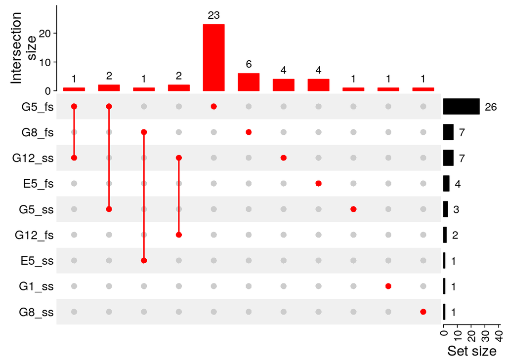

```r
# These are genes that change in only 1 resistant line
# DEP_Bl_Res_fs_unique_genes_ls
# DEP_Bl_Res_ss_unique_genes_ls

# Filter out intersecting genes
filt_DEP_Bl_Res_fs_unique_genes_ls <- lapply(DEP_Bl_Res_fs_unique_genes_ls, function(x) x[!(x %in% intersect_genes)])
filt_DEP_Bl_Res_ss_unique_genes_ls <- lapply(DEP_Bl_Res_ss_unique_genes_ls, function(x) x[!(x %in% intersect_genes)])

# Combine fs and ss genes
DEP_Bl_Res_unique_genes_ls <- c(filt_DEP_Bl_Res_fs_unique_genes_ls,filt_DEP_Bl_Res_ss_unique_genes_ls)

# Directories
output_dir_upset <- paste0(figures_dir)
graph_dir_upset <- paste0(figures_dir)

# Convert list to binary matrix
Upset_matrix <- ComplexHeatmap::list_to_matrix(DEP_Bl_Res_unique_genes_ls)

# Save Upset_matrix
write.csv(Upset_matrix, file = paste0(output_dir_upset, "Baseline_Clone_Kinase_Sig_Upset_matrix",".csv"))

# convert list to combination matrix
combo_matrix <- ComplexHeatmap::make_comb_mat(Upset_matrix)

# Generate upset plot
upset_plot <- ComplexHeatmap::UpSet(combo_matrix, comb_col = "red" ,
                        row_names_gp =gpar(fontsize = 12) ,
                        top_annotation = upset_top_annotation(
                          combo_matrix,
                          add_numbers = TRUE,
                          numbers_gp = gpar(fontsize = 11),
                          numbers_rot=0,
                          annotation_name_rot = 90,
                          axis_param=list (gp = gpar(fontsize = 11)),
                          annotation_name_gp= gpar(fontsize = 14)),
                        right_annotation = upset_right_annotation(
                          combo_matrix,
                          add_numbers = TRUE,
                          numbers_gp = gpar(fontsize = 11),
                          numbers_rot=0,
                          axis_param=list (gp = gpar(fontsize = 11)),
                          annotation_name_gp= gpar(fontsize = 14)),
                        pt_size = unit(8, "pt"))

upset_plot
```

```r
# Save upset_plot
pdf(file=paste0(graph_dir_upset, "Baseline_Clone_Kinase_Sig_Upset" , ".pdf"))
draw(upset_plot)
dev.off()
```

```r
# Combination matrix
combo_matrix
```

```
## A combination matrix with 9 sets and 11 combinations.
##   ranges of combination set size: c(1, 23).
##   mode for the combination size: distinct.
##   sets are on rows.
##
## Top 8 combination sets are:
##   E5_fs G5_fs G8_fs G12_fs E5_ss G1_ss G5_ss G8_ss G12_ss      code size
##             x                                             010000000   23
##                   x                                       001000000    6
##       x                                                   100000000    4
##                                                         x 000000001    4
##             x                              x              010000100    2
##                          x                              x 000100001    2
##             x                                           x 010000001    1
##                   x            x                          001010000    1
##
## Sets are:
##      set size
##    E5_fs    4
##    G5_fs   26
##    G8_fs    7
##   G12_fs    2
##    E5_ss    1
##    G1_ss    1
##    G5_ss    3
##    G8_ss    1
##   G12_ss    7
```

```r
comb_name(combo_matrix)
```

```
##  [1] "010000100" "010000001" "001010000" "000100001" "100000000" "010000000"
##  [7] "001000000" "000001000" "000000100" "000000010" "000000001"
```

```r
# Extract all from upset plot
upset_genes_ls <- list()
for(i in seq_along(comb_name(combo_matrix))){
  upset_genes_ls[[paste0((set_name(combo_matrix)["1"==strsplit(comb_name(combo_matrix)[i],"")[[1]]])[1],"_",(set_name(combo_matrix)["1"==strsplit(comb_name(combo_matrix)[i],"")[[1]]])[2],"_",(set_name(combo_matrix)["1"==strsplit(comb_name(combo_matrix)[i],"")[[1]]])[3],"_",(set_name(combo_matrix)["1"==strsplit(comb_name(combo_matrix)[i],"")[[1]]])[4],"_",(set_name(combo_matrix)["1"==strsplit(comb_name(combo_matrix)[i],"")[[1]]])[5],"_",(set_name(combo_matrix)["1"==strsplit(comb_name(combo_matrix)[i],"")[[1]]])[6],"_",(set_name(combo_matrix)["1"==strsplit(comb_name(combo_matrix)[i],"")[[1]]])[7],"_",(set_name(combo_matrix)["1"==strsplit(comb_name(combo_matrix)[i],"")[[1]]])[8],"_",(set_name(combo_matrix)["1"==strsplit(comb_name(combo_matrix)[i],"")[[1]]])[9],"_",(set_name(combo_matrix)["1"==strsplit(comb_name(combo_matrix)[i],"")[[1]]])[10],"_",(set_name(combo_matrix)["1"==strsplit(comb_name(combo_matrix)[i],"")[[1]]])[11])]] <-
    extract_comb(combo_matrix,comb_name(combo_matrix)[i])
}

# Convert to DF
upset_genes_df <- do.call(cbind, lapply(upset_genes_ls, function(x) c(x, rep(NA, max(sapply(upset_genes_ls, length)) - length(x)))))


# Save genes
write.csv(upset_genes_df, file = paste0(output_dir_upset,"Baseline_Clone_Kinase_Sig_genes_df",".csv"))

# Extract unique genes
grep("_NA_NA_NA_NA_NA_NA_NA_NA_NA_NA",colnames(upset_genes_df))
```

```
## [1]  5  6  7  8  9 10 11
```

```r
DEP_Bl_Res_unique_genes_ol <- c()
for(i in (grep("_NA_NA_NA_NA_NA_NA_NA_NA_NA_NA",colnames(upset_genes_df)))){
  DEP_Bl_Res_unique_genes_ol<- c(DEP_Bl_Res_unique_genes_ol,upset_genes_df[,i][!is.na( upset_genes_df[,i])])
}

# Subset unique genes DF
DEP_Bl_Res_unique_genes_ol_df <- upset_genes_df[,colnames(upset_genes_df)[grep("_NA_NA_NA_NA_NA_NA_NA_NA_NA_NA",colnames(upset_genes_df))]]
colnames(DEP_Bl_Res_unique_genes_ol_df) <- gsub("_NA_NA_NA_NA_NA_NA_NA_NA_NA_NA","",colnames(DEP_Bl_Res_unique_genes_ol_df))

# Convert to list
DEP_Bl_Res_unique_genes_ol_ls <- list()
for (i in seq_along(colnames(DEP_Bl_Res_unique_genes_ol_df))){
  DEP_Bl_Res_unique_genes_ol_ls[[colnames(DEP_Bl_Res_unique_genes_ol_df)[i]]] <-
    c(DEP_Bl_Res_unique_genes_ol_df[,i][!is.na(DEP_Bl_Res_unique_genes_ol_df[,i])])
}

# Extract overlapping genes column names
colnames(upset_genes_df)[(grep("_NA_NA_NA_NA_NA_NA_NA_NA_NA_NA",colnames(upset_genes_df), invert = T))]
```

```
## [1] "G5_fs_G5_ss_NA_NA_NA_NA_NA_NA_NA_NA_NA"
## [2] "G5_fs_G12_ss_NA_NA_NA_NA_NA_NA_NA_NA_NA"
## [3] "G8_fs_E5_ss_NA_NA_NA_NA_NA_NA_NA_NA_NA"
## [4] "G12_fs_G12_ss_NA_NA_NA_NA_NA_NA_NA_NA_NA"
```

```r
# Extract overlapping genes
DEP_Bl_Res_unique_genes_ol_ol_genes <- c()
for (i in (colnames(upset_genes_df)[(grep("_NA_NA_NA_NA_NA_NA_NA_NA_NA_NA",colnames(upset_genes_df), invert = T))])){
  DEP_Bl_Res_unique_genes_ol_ol_genes <-
    c(DEP_Bl_Res_unique_genes_ol_ol_genes,upset_genes_df[,i][!is.na( upset_genes_df[,i] )])

}
```

## Save Unique Basline signatures

```r
DEP_Bl_Res_unique_genes_ol_ls
```

```
## $E5_fs
## [1] "Gsk3b"  "Mapk10" "Phkg2"  "Pik3r4"
##
## $G5_fs
##  [1] "Axl"     "Bub1b"   "Cdk13"   "Chek2"   "Chka"    "Clk3"    "Dck"
##  [8] "Fn3krp"  "Ikbke"   "Jak1"    "Lrrk2"   "Lyn"     "Mark3"   "Nek3"
## [15] "Nek9"    "Prkaa1"  "Prkacb"  "Prkce"   "Rps6kc1" "Stk38"   "Stk38l"
## [22] "Tesk1"   "Tnk2"
##
## $G8_fs
## [1] "Bmpr1a"  "Csnk2a1" "Mapk8"   "Mark2"   "Prkd3"   "Ulk1"
##
## $G1_ss
## [1] "Chkb"
##
## $G5_ss
## [1] "Brsk2"
##
## $G8_ss
## [1] "Nrbp1"
##
## $G12_ss
## [1] "Braf" "Cdk1" "Cdk4" "Jak3"
```

```r
names(DEP_Bl_Res_unique_genes_ol_ls)
```

```
## [1] "E5_fs"  "G5_fs"  "G8_fs"  "G1_ss"  "G5_ss"  "G8_ss"  "G12_ss"
```

```r
E5_BL_sig <- DEP_Bl_Res_unique_genes_ol_ls[["E5_fs"]]
G1_BL_sig <- DEP_Bl_Res_unique_genes_ol_ls[["G1_fs"]]
G5_BL_sig <- DEP_Bl_Res_unique_genes_ol_ls[["G5_fs"]]
G8_BL_sig <- DEP_Bl_Res_unique_genes_ol_ls[["G8_fs"]]
G12_BL_sig <- c(DEP_Bl_Res_unique_genes_ol_ls[["G12_fs"]],DEP_Bl_Res_unique_genes_ol_ls[["G12_ss"]])

BL_sig_ls <- list(E5_BL_sig=E5_BL_sig,
                  G1_BL_sig=G1_BL_sig,
                  G5_BL_sig=G5_BL_sig,
                  G8_BL_sig=G8_BL_sig,
                  G12_BL_sig=G12_BL_sig)


BL_sig_df <- do.call(cbind, lapply(BL_sig_ls, function(x) c(x, rep(NA, max(sapply(BL_sig_ls, length)) - length(x)))))

write.csv(BL_sig_df, file = paste0(output_dir_upset,"Clone_baseline_sig",".csv"), na="")
```

## Shared_kinase_sig

### Fig.3D

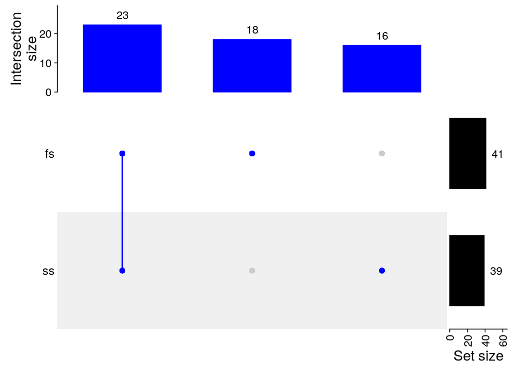

```r
# These are kinases that change in more than one resistant line.
# DEP_Bl_Res_fs_ol_genes
# DEP_Bl_Res_ss_ol_genes

# Filter out intersecting genes
filt_DEP_Bl_Res_fs_ol_genes <- DEP_Bl_Res_fs_ol_genes[!(DEP_Bl_Res_fs_ol_genes %in% intersect_genes)]
filt_DEP_Bl_Res_ss_ol_genes <- DEP_Bl_Res_ss_ol_genes[!(DEP_Bl_Res_ss_ol_genes %in% intersect_genes)]

# Combine fs and ss genes
serum_unique_genes_ls <- list(fs = filt_DEP_Bl_Res_fs_ol_genes,
                              ss = filt_DEP_Bl_Res_ss_ol_genes)

# Directories
output_dir_upset <- paste0(figures_dir)
graph_dir_upset <- paste0(figures_dir)


# Convert list to binary matrix
Upset_matrix <- ComplexHeatmap::list_to_matrix(serum_unique_genes_ls)

# Save Upset_matrix
write.csv(Upset_matrix, file = paste0(output_dir_upset, "Shared_kinase_Upset_matrix",".csv"))

# convert list to combination matrix
combo_matrix <- ComplexHeatmap::make_comb_mat(Upset_matrix)

# Generate upset plot
upset_plot <- ComplexHeatmap::UpSet(combo_matrix, comb_col = "blue" ,
                        row_names_gp =gpar(fontsize = 12) ,
                        top_annotation = upset_top_annotation(
                          combo_matrix,
                          add_numbers = TRUE,
                          numbers_gp = gpar(fontsize = 11),
                          numbers_rot=0,
                          annotation_name_rot = 90,
                          axis_param=list (gp = gpar(fontsize = 11)),
                          annotation_name_gp= gpar(fontsize = 14)),
                        right_annotation = upset_right_annotation(
                          combo_matrix,
                          add_numbers = TRUE,
                          numbers_gp = gpar(fontsize = 11),
                          numbers_rot=0,
                          axis_param=list (gp = gpar(fontsize = 11)),
                          annotation_name_gp= gpar(fontsize = 14)),
                        pt_size = unit(8, "pt"))

upset_plot
```

```r
# Save upset_plot
pdf(file=paste0(graph_dir_upset, "Shared_kinase_Upset" , ".pdf"))
draw(upset_plot)
dev.off()
```

```r
# Combination matrix
combo_matrix
```

```
## A combination matrix with 2 sets and 3 combinations.
##   ranges of combination set size: c(16, 23).
##   mode for the combination size: distinct.
##   sets are on rows.
##
## Combination sets are:
##   fs ss code size
##    x  x   11   23
##    x      10   18
##       x   01   16
##
## Sets are:
##   set size
##    fs   41
##    ss   39
```

```r
comb_name(combo_matrix)
```

```
## [1] "11" "10" "01"
```

```r
# Extract all from upset plot
upset_genes_ls <- list()
for(i in seq_along(comb_name(combo_matrix))){
  upset_genes_ls[[paste0((set_name(combo_matrix)["1"==strsplit(comb_name(combo_matrix)[i],"")[[1]]])[1],"_",(set_name(combo_matrix)["1"==strsplit(comb_name(combo_matrix)[i],"")[[1]]])[2])]] <-
    extract_comb(combo_matrix,comb_name(combo_matrix)[i])
}

# Convert to DF
upset_genes_df <- do.call(cbind, lapply(upset_genes_ls, function(x) c(x, rep(NA, max(sapply(upset_genes_ls, length)) - length(x)))))


# Save genes
write.csv(upset_genes_df, file = paste0(output_dir_upset,"Shared_kinase_upset_genes_df",".csv"))

# Extract fs_ss Ol
fs_ss_ol_kinases <- data.frame(upset_genes_df)["fs_ss"][!is.na(data.frame(upset_genes_df)["fs_ss"])]
```

## All_Baseline_kinase_sig

```r
DEP_Bl_Res_unique_genes_ol_ls
```

```
## $E5_fs
## [1] "Gsk3b"  "Mapk10" "Phkg2"  "Pik3r4"
##
## $G5_fs
##  [1] "Axl"     "Bub1b"   "Cdk13"   "Chek2"   "Chka"    "Clk3"    "Dck"
##  [8] "Fn3krp"  "Ikbke"   "Jak1"    "Lrrk2"   "Lyn"     "Mark3"   "Nek3"
## [15] "Nek9"    "Prkaa1"  "Prkacb"  "Prkce"   "Rps6kc1" "Stk38"   "Stk38l"
## [22] "Tesk1"   "Tnk2"
##
## $G8_fs
## [1] "Bmpr1a"  "Csnk2a1" "Mapk8"   "Mark2"   "Prkd3"   "Ulk1"
##
## $G1_ss
## [1] "Chkb"
##
## $G5_ss
## [1] "Brsk2"
##
## $G8_ss
## [1] "Nrbp1"
##
## $G12_ss
## [1] "Braf" "Cdk1" "Cdk4" "Jak3"
```

```r
names(DEP_Bl_Res_unique_genes_ol_ls)
```

```
## [1] "E5_fs"  "G5_fs"  "G8_fs"  "G1_ss"  "G5_ss"  "G8_ss"  "G12_ss"
```

```r
E5_BL_sig <- c(DEP_Bl_Res_unique_genes_ol_ls[["E5_fs"]],DEP_Bl_Res_unique_genes_ol_ls[["E5_ss"]])
G1_BL_sig <- c(DEP_Bl_Res_unique_genes_ol_ls[["G1_fs"]],DEP_Bl_Res_unique_genes_ol_ls[["G1_ss"]])
G5_BL_sig <- c(DEP_Bl_Res_unique_genes_ol_ls[["G5_fs"]],DEP_Bl_Res_unique_genes_ol_ls[["G5_ss"]])
G8_BL_sig <- c(DEP_Bl_Res_unique_genes_ol_ls[["G8_fs"]],DEP_Bl_Res_unique_genes_ol_ls[["G8_ss"]])
G12_BL_sig <- c(DEP_Bl_Res_unique_genes_ol_ls[["G12_fs"]],DEP_Bl_Res_unique_genes_ol_ls[["G12_ss"]])

# Genes that overlap and are not influenced by serum
OL_BL_sig <- intersect(serum_unique_genes_ls[["fs"]],serum_unique_genes_ls[["ss"]])

BL_sig_ls <- list(E5_BL_sig=E5_BL_sig,
                  G1_BL_sig=G1_BL_sig,
                  G5_BL_sig=G5_BL_sig,
                  G8_BL_sig=G8_BL_sig,
                  G12_BL_sig=G12_BL_sig,
                  OL_BL_sig=OL_BL_sig)

BL_sig_df <- do.call(cbind, lapply(BL_sig_ls, function(x) c(x, rep(NA, max(sapply(BL_sig_ls, length)) - length(x)))))

# Save CSV
write.csv(BL_sig_df, file = paste0(output_dir_upset,"All_baseline_kinase_sig",".csv"), na="")


# Sanity check. There should be no differences between the baseline signatures generated in this Figures script compared to the EDA script.

# Import figures sigs
BL_sig_df_figures <- read.csv(paste0(output_dir_upset,"All_baseline_kinase_sig.csv"), header =TRUE, fileEncoding = "UTF-8-BOM", row.names = 1, na.strings = NA)

# Import EDA sigs
BL_sig_df_EDA <- read.csv("/Data/Output/MIB_BL_sig/ss_fs_ol/BL_sig.csv", header =TRUE, fileEncoding = "UTF-8-BOM", row.names = 1, na.strings = NA)

# Compare results
waldo::compare(BL_sig_df_figures,BL_sig_df_EDA)
```

```
## ✔ No differences
```

# Baseline Signatures

Setup

```r
# Clean environment
rm(list = ls())
gc()
```

```
##            used  (Mb) gc trigger   (Mb) max used   (Mb)
## Ncells 15683978 837.7   25160558 1343.8 25160558 1343.8
## Vcells 27421569 209.3   47131234  359.6 42568578  324.8
```

```r
# Import setup workspace
load(paste0("/Data/Input/Figures/setup_workspace.RData"))
```

Directories

```r
fig.label <- paste0("Baseline_signatures")
figures_dir <- paste0(Data,"Figures/",fig.label,"/")
dir.create(figures_dir)
```

## Signature import (Unique)

```r
# BL_sig
BL_sigs_df <- read.csv(paste0(Data,"Figures/","Baseline_kinase_upset/","All_baseline_kinase_sig.csv"), row.names = 1, na.strings = c("","NA"))

# Pivot
df_long <- BL_sigs_df %>%
  pivot_longer(cols = everything(), values_to = "gene")

# Remove NA
BL_sig <- subset(df_long,!df_long$gene=="")

# # Remove OL sig
BL_sig <- subset(BL_sig,BL_sig$name!="OL_BL_sig")

# Remove hEGFR
BL_sig <- subset(BL_sig,!BL_sig$gene=="hEGFR")

# Remove text
BL_sig$name <- gsub("_BL_sig","",BL_sig$name)
```

### Protein fs

#### Fig.4A

```r
# Import Protein vsd
DEP_Bl_Res_fs <- readRDS(tail(grep("DEP_Bl_Res_fs.rds",list.files(paste0(Data,"Output/MIB-BL/DEP_Bl_Res_fs"), recursive = T, full.names = T), value = T),1))
DEP_Bl_Res_ss <- readRDS(tail(grep("DEP_Bl_Res_ss.rds",list.files(paste0(Data,"Output/MIB-BL/DEP_Bl_Res_ss"), recursive = T, full.names = T), value = T),1))

# # Import mRNA vsd
# DEP_Bl_Res_fs <- readRDS(tail(grep("bl_Res_fs_mv_.rds",list.files(paste0(Data,"Output/MIB-BL/DEP_EDA_subset/bl_Res_fs"), recursive = T, full.names = T), value = T),1))
# DEP_Bl_Res_ss <- readRDS(tail(grep("bl_Res_ss_mv_.rds",list.files(paste0(Data,"Output/MIB-BL/DEP_EDA_subset/bl_Res_ss"), recursive = T, full.names = T), value = T),1))
#

# Combined full and starved Protein
DEP_Bl_Res_all <- cbind(DEP_Bl_Res_fs,DEP_Bl_Res_ss)

# Already log2 transformed
vsd <- DEP_Bl_Res_fs

# Subset dds to contain genes in sig
vsd_sig <-vsd[row.names(vsd) %in% BL_sig$gene,]

# Divide by mean of CEv3
CEv3_samples <- row.names(subset(colData(vsd_sig),colData(vsd_sig)$cell_line_abbr=="CEv3"))

# Get mean of CEv3
vsd_CEv3 <- vsd_sig[,colnames(vsd_sig) %in% CEv3_samples]
CEv3_RowMean <- data.frame(rowMeans(assay(vsd_CEv3)[,colnames(vsd_CEv3) %in% CEv3_samples]))

# Check
row.names(assay(vsd_sig))==row.names(CEv3_RowMean)
```

```
##  [1] TRUE TRUE TRUE TRUE TRUE TRUE TRUE TRUE TRUE TRUE TRUE TRUE TRUE TRUE TRUE
## [16] TRUE TRUE TRUE TRUE TRUE TRUE TRUE TRUE TRUE TRUE TRUE TRUE TRUE TRUE TRUE
## [31] TRUE TRUE TRUE TRUE TRUE TRUE TRUE TRUE TRUE TRUE
```

```r
# Calculate Normalized values
vsd_sig_norm <- vsd_sig
assay(vsd_sig_norm) <- sweep(assay(vsd_sig),1,CEv3_RowMean[,1])

# Remove CEv3 samples
vsd_sig_norm <- vsd_sig_norm[,!(colnames(vsd_sig_norm) %in% CEv3_samples)]

# Heatmap_GOI_df_ls
heatmap_goi <- data.frame(BL_sig)
heatmap_goi$name <- as.factor(heatmap_goi$name)
row.names(heatmap_goi) <- heatmap_goi$gene

# Extract matrix values
mat_list <- as.matrix(assay(vsd_sig_norm))

# Heatmap annotation labels
annotation_col <- HeatmapAnnotation(df = data.frame(Model = factor(vsd_sig_norm@colData$cell_line_abbr,
                                                    # Set legend order
                                                    levels= c("E4","E5","G1","G5","G8","G12")),
                                    Serum = vsd_sig_norm@colData$serum),
  col = list(Model =
  c(
    'E4' = 'deepskyblue4',
    'E5' = 'turquoise3',
    'G1' = 'purple4',
    'G5' = 'mediumorchid',
    'G8' = 'deeppink',
    'G12' = 'pink2'
    ),
  Serum =
    c("full"='firebrick',
      "starve"='royalblue'
      )
  ))

# Generate Heatmap
Heatmap <- ComplexHeatmap::Heatmap(
  t(scale(t(mat_list))),
  top_annotation = annotation_col,
  name = " ",
  column_split = vsd_sig_norm@colData$cell_line_abbr,
  column_title = "Protein FS",
  row_split = heatmap_goi[row.names(mat_list),]["name"] ,
  row_gap = unit(1, "mm"),
  show_column_names = F,
  show_row_names = T,
  row_names_gp = gpar(fontsize = 8),
  row_title_gp = gpar(fontsize = 8),
  width = ncol(mat_list)*unit(5, "mm"),
  height = nrow(mat_list)*unit(2.5, "mm")
  )

draw(Heatmap)
```

[output not shown]

```r
# Get height and width of heatmap for pdf
width = convertX(ComplexHeatmap:::width(draw(Heatmap)), "inch", valueOnly = TRUE)
```

```r
height = convertY(ComplexHeatmap:::height(draw(Heatmap)), "inch", valueOnly = TRUE)
```

```r
pdf(file=paste0(figures_dir, "Protein_fs_sig", ".pdf"), width = width+(0.01*width), height = height+(0.01*height))
draw(Heatmap)
dev.off()
```

### Protein ss

#### Fig.4B

```r
# Import Protein vsd
DEP_Bl_Res_fs <- readRDS(tail(grep("DEP_Bl_Res_fs.rds",list.files(paste0(Data,"Output/MIB-BL/DEP_Bl_Res_fs"), recursive = T, full.names = T), value = T),1))
DEP_Bl_Res_ss <- readRDS(tail(grep("DEP_Bl_Res_ss.rds",list.files(paste0(Data,"Output/MIB-BL/DEP_Bl_Res_ss"), recursive = T, full.names = T), value = T),1))

# DEP_Bl_Res_fs <- readRDS(tail(grep("bl_Res_fs_mv_.rds",list.files(paste0(Data,"Output/MIB-BL/DEP_EDA_subset/bl_Res_fs"), recursive = T, full.names = T), value = T),1))
# DEP_Bl_Res_ss <- readRDS(tail(grep("bl_Res_ss_mv_.rds",list.files(paste0(Data,"Output/MIB-BL/DEP_EDA_subset/bl_Res_ss"), recursive = T, full.names = T), value = T),1))

# Combined full and starved Protein
DEP_Bl_Res_all <- cbind(DEP_Bl_Res_fs,DEP_Bl_Res_ss)

# Already log2 transformed
vsd <- DEP_Bl_Res_ss

# Subset dds to contain genes in sig
vsd_sig <-vsd[row.names(vsd) %in% BL_sig$gene,]

# Divide by mean of CEv3
CEv3_samples <- row.names(subset(colData(vsd_sig),colData(vsd_sig)$cell_line_abbr=="CEv3"))

# Get mean of CEv3
vsd_CEv3 <- vsd_sig[,colnames(vsd_sig) %in% CEv3_samples]
CEv3_RowMean <- data.frame(rowMeans(assay(vsd_CEv3)[,colnames(vsd_CEv3) %in% CEv3_samples]))

# Check
row.names(assay(vsd_sig))==row.names(CEv3_RowMean)
```

```
##  [1] TRUE TRUE TRUE TRUE TRUE TRUE TRUE TRUE TRUE TRUE TRUE TRUE TRUE TRUE TRUE
## [16] TRUE TRUE TRUE TRUE TRUE TRUE TRUE TRUE TRUE TRUE TRUE TRUE TRUE TRUE TRUE
## [31] TRUE TRUE TRUE TRUE TRUE TRUE TRUE TRUE TRUE TRUE
```

```r
# Calculate Normalized values
vsd_sig_norm <- vsd_sig
assay(vsd_sig_norm) <- sweep(assay(vsd_sig),1,CEv3_RowMean[,1])

# Remove CEv3 samples
vsd_sig_norm <- vsd_sig_norm[,!(colnames(vsd_sig_norm) %in% CEv3_samples)]

# Heatmap_GOI_df_ls
heatmap_goi <- data.frame(BL_sig)
heatmap_goi$name <- as.factor(heatmap_goi$name)
row.names(heatmap_goi) <- heatmap_goi$gene

# Extract matrix values
mat_list <- as.matrix(assay(vsd_sig_norm))

# Heatmap annotation labels
annotation_col <- HeatmapAnnotation(df = data.frame(Model = factor(vsd_sig_norm@colData$cell_line_abbr,
                                                    # Set legend order
                                                    levels= c("E4","E5","G1","G5","G8","G12")),
                                    Serum = vsd_sig_norm@colData$serum),
  col = list(Model =
  c(
    'E4' = 'deepskyblue4',
    'E5' = 'turquoise3',
    'G1' = 'purple4',
    'G5' = 'mediumorchid',
    'G8' = 'deeppink',
    'G12' = 'pink2'
    ),
  Serum =
    c("full"='firebrick',
      "starve"='royalblue'
      )
  ))


# Generate Heatmap
Heatmap <- ComplexHeatmap::Heatmap(
  t(scale(t(mat_list))),
  top_annotation = annotation_col,
  name = " ",
  column_split = vsd_sig_norm@colData$cell_line_abbr,
  column_title = "Protein SS",
  row_split = heatmap_goi[row.names(mat_list),]["name"] ,
  row_gap = unit(1, "mm"),
  show_column_names = F,
  show_row_names = T,
  row_names_gp = gpar(fontsize = 8),
  row_title_gp = gpar(fontsize = 8),
  width = ncol(mat_list)*unit(5, "mm"),
  height = nrow(mat_list)*unit(2.5, "mm")
  )

draw(Heatmap)
```

[output not shown]

```r
# Get height and width of heatmap for pdf
width = convertX(ComplexHeatmap:::width(draw(Heatmap)), "inch", valueOnly = TRUE)
```

```r
height = convertY(ComplexHeatmap:::height(draw(Heatmap)), "inch", valueOnly = TRUE)
```

```r
pdf(file=paste0(figures_dir, "Protein_ss_sig", ".pdf"), width = width+(0.01*width), height = height+(0.01*height))
draw(Heatmap)
dev.off()
```

## Signature import (OL)

```r
# BL_sig
BL_sigs_df <- read.csv(paste0(Data,"Figures/","Baseline_kinase_upset/","All_baseline_kinase_sig.csv"), row.names = 1, na.strings = c("","NA"))

# Pivot
df_long <- BL_sigs_df %>%
  pivot_longer(cols = everything(), values_to = "gene")

# Remove NA
BL_sig <- subset(df_long,!df_long$gene=="")

# Remove unique sig
BL_sig <- subset(BL_sig,BL_sig$name=="OL_BL_sig")

# Remove hEGFR
BL_sig <- subset(BL_sig,!BL_sig$gene=="hEGFR")

# Remove text
BL_sig$name <- gsub("_BL_sig","",BL_sig$name)
```

### Protein fs

#### Fig.4C

```r
# Import Protein vsd
DEP_Bl_Res_fs <- readRDS(tail(grep("DEP_Bl_Res_fs.rds",list.files(paste0(Data,"Output/MIB-BL/DEP_Bl_Res_fs"), recursive = T, full.names = T), value = T),1))
DEP_Bl_Res_ss <- readRDS(tail(grep("DEP_Bl_Res_ss.rds",list.files(paste0(Data,"Output/MIB-BL/DEP_Bl_Res_ss"), recursive = T, full.names = T), value = T),1))

# # # Import mRNA vsd
# # DEP_Bl_Res_fs <- readRDS(tail(grep("bl_Res_fs_mv_.rds",list.files(paste0(Data,"Output/MIB-BL/DEP_EDA_subset/bl_Res_fs"), recursive = T, full.names = T), value = T),1))
# # DEP_Bl_Res_ss <- readRDS(tail(grep("bl_Res_ss_mv_.rds",list.files(paste0(Data,"Output/MIB-BL/DEP_EDA_subset/bl_Res_ss"), recursive = T, full.names = T), value = T),1))
# #
#
# # Combined full and starved Protein
# DEP_Bl_Res_all <- cbind(DEP_Bl_Res_fs,DEP_Bl_Res_ss)

# Already log2 transformed
vsd <- DEP_Bl_Res_fs

# Subset dds to contain genes in sig
vsd_sig <-vsd[row.names(vsd) %in% BL_sig$gene,]

# Divide by mean of CEv3
CEv3_samples <- row.names(subset(colData(vsd_sig),colData(vsd_sig)$cell_line_abbr=="CEv3"))

# Get mean of CEv3
vsd_CEv3 <- vsd_sig[,colnames(vsd_sig) %in% CEv3_samples]
CEv3_RowMean <- data.frame(rowMeans(assay(vsd_CEv3)[,colnames(vsd_CEv3) %in% CEv3_samples]))

# Check
row.names(assay(vsd_sig))==row.names(CEv3_RowMean)
```

```
##  [1] TRUE TRUE TRUE TRUE TRUE TRUE TRUE TRUE TRUE TRUE TRUE TRUE TRUE TRUE TRUE
## [16] TRUE TRUE TRUE TRUE TRUE TRUE TRUE TRUE
```

```r
# Calculate Normalized values
vsd_sig_norm <- vsd_sig
assay(vsd_sig_norm) <- sweep(assay(vsd_sig),1,CEv3_RowMean[,1])

# Clip values
assay(vsd_sig_norm) <- pmax(pmin(assay(vsd_sig_norm),4),-4)

# Remove CEv3 samples
vsd_sig_norm <- vsd_sig_norm[,!(colnames(vsd_sig_norm) %in% CEv3_samples)]



# Heatmap_GOI_df_ls
heatmap_goi <- data.frame(BL_sig)
heatmap_goi$name <- as.factor(heatmap_goi$name)
row.names(heatmap_goi) <- heatmap_goi$gene

# Extract matrix values
mat_list <- as.matrix(assay(vsd_sig_norm))

# Heatmap annotation labels
annotation_col <- HeatmapAnnotation(df = data.frame(Model = factor(vsd_sig_norm@colData$cell_line_abbr,
                                                    # Set legend order
                                                    levels= c("E4","E5","G1","G5","G8","G12")),
                                    Serum = vsd_sig_norm@colData$serum),
  col = list(Model =
  c(
    'E4' = 'deepskyblue4',
    'E5' = 'turquoise3',
    'G1' = 'purple4',
    'G5' = 'mediumorchid',
    'G8' = 'deeppink',
    'G12' = 'pink2'
    ),
  Serum =
    c("full"='firebrick',
      "starve"='royalblue'
      )
  ))

# Generate Heatmap
Heatmap <- ComplexHeatmap::Heatmap(
  mat_list,
  top_annotation = annotation_col,
  name = " ",
  column_split = vsd_sig_norm@colData$cell_line_abbr,
  column_title = "Protein FS",
  row_split = heatmap_goi[row.names(mat_list),]["name"] ,
  row_gap = unit(1, "mm"),
  show_column_names = F,
  show_row_names = T,
  row_names_gp = gpar(fontsize = 8),
  row_title_gp = gpar(fontsize = 8),
  width = ncol(mat_list)*unit(5, "mm"),
  height = nrow(mat_list)*unit(2.5, "mm")
  )

draw(Heatmap)
```

[output not shown]

```r
# Get height and width of heatmap for pdf
width = convertX(ComplexHeatmap:::width(draw(Heatmap)), "inch", valueOnly = TRUE)
```

```r
height = convertY(ComplexHeatmap:::height(draw(Heatmap)), "inch", valueOnly = TRUE)
```

```r
pdf(file=paste0(figures_dir, "OL_Protein_fs_sig", ".pdf"), width = width+(0.01*width), height = height+(0.01*height))
draw(Heatmap)
dev.off()
```

### Protein ss

#### Fig.4D

```r
# Import Protein vsd
DEP_Bl_Res_fs <- readRDS(tail(grep("DEP_Bl_Res_fs.rds",list.files(paste0(Data,"Output/MIB-BL/DEP_Bl_Res_fs"), recursive = T, full.names = T), value = T),1))
DEP_Bl_Res_ss <- readRDS(tail(grep("DEP_Bl_Res_ss.rds",list.files(paste0(Data,"Output/MIB-BL/DEP_Bl_Res_ss"), recursive = T, full.names = T), value = T),1))

# DEP_Bl_Res_fs <- readRDS(tail(grep("bl_Res_fs_mv_.rds",list.files(paste0(Data,"Output/MIB-BL/DEP_EDA_subset/bl_Res_fs"), recursive = T, full.names = T), value = T),1))
# DEP_Bl_Res_ss <- readRDS(tail(grep("bl_Res_ss_mv_.rds",list.files(paste0(Data,"Output/MIB-BL/DEP_EDA_subset/bl_Res_ss"), recursive = T, full.names = T), value = T),1))

# Combined full and starved Protein
DEP_Bl_Res_all <- cbind(DEP_Bl_Res_fs,DEP_Bl_Res_ss)

# Already log2 transformed
vsd <- DEP_Bl_Res_ss

# Subset dds to contain genes in sig
vsd_sig <-vsd[row.names(vsd) %in% BL_sig$gene,]

# Divide by mean of CEv3
CEv3_samples <- row.names(subset(colData(vsd_sig),colData(vsd_sig)$cell_line_abbr=="CEv3"))

# Get mean of CEv3
vsd_CEv3 <- vsd_sig[,colnames(vsd_sig) %in% CEv3_samples]
CEv3_RowMean <- data.frame(rowMeans(assay(vsd_CEv3)[,colnames(vsd_CEv3) %in% CEv3_samples]))

# Check
row.names(assay(vsd_sig))==row.names(CEv3_RowMean)
```

```
##  [1] TRUE TRUE TRUE TRUE TRUE TRUE TRUE TRUE TRUE TRUE TRUE TRUE TRUE TRUE TRUE
## [16] TRUE TRUE TRUE TRUE TRUE TRUE TRUE TRUE
```

```r
# Calculate Normalized values
vsd_sig_norm <- vsd_sig
assay(vsd_sig_norm) <- sweep(assay(vsd_sig),1,CEv3_RowMean[,1])

# Clip values
assay(vsd_sig_norm) <- pmax(pmin(assay(vsd_sig_norm),4),-4)

# Remove CEv3 samples
vsd_sig_norm <- vsd_sig_norm[,!(colnames(vsd_sig_norm) %in% CEv3_samples)]

# Heatmap_GOI_df_ls
heatmap_goi <- data.frame(BL_sig)
heatmap_goi$name <- as.factor(heatmap_goi$name)
row.names(heatmap_goi) <- heatmap_goi$gene

# Extract matrix values
mat_list <- as.matrix(assay(vsd_sig_norm))

# Heatmap annotation labels
annotation_col <- HeatmapAnnotation(df = data.frame(Model = factor(vsd_sig_norm@colData$cell_line_abbr,
                                                    # Set legend order
                                                    levels= c("E4","E5","G1","G5","G8","G12")),
                                    Serum = vsd_sig_norm@colData$serum),
  col = list(Model =
  c(
    'E4' = 'deepskyblue4',
    'E5' = 'turquoise3',
    'G1' = 'purple4',
    'G5' = 'mediumorchid',
    'G8' = 'deeppink',
    'G12' = 'pink2'
    ),
  Serum =
    c("full"='firebrick',
      "starve"='royalblue'
      )
  ))


# Generate Heatmap
Heatmap <- ComplexHeatmap::Heatmap(
  mat_list,
  top_annotation = annotation_col,
  name = " ",
  column_split = vsd_sig_norm@colData$cell_line_abbr,
  column_title = "Protein SS",
  row_split = heatmap_goi[row.names(mat_list),]["name"] ,
  row_gap = unit(1, "mm"),
  show_column_names = F,
  show_row_names = T,
  row_names_gp = gpar(fontsize = 8),
  row_title_gp = gpar(fontsize = 8),
  width = ncol(mat_list)*unit(5, "mm"),
  height = nrow(mat_list)*unit(2.5, "mm")
  )

draw(Heatmap)
```

[output not shown]

```r
# Get height and width of heatmap for pdf
width = convertX(ComplexHeatmap:::width(draw(Heatmap)), "inch", valueOnly = TRUE)
```

```r
height = convertY(ComplexHeatmap:::height(draw(Heatmap)), "inch", valueOnly = TRUE)
```

```r
pdf(file=paste0(figures_dir, "OL_Protein_ss_sig", ".pdf"), width = width+(0.01*width), height = height+(0.01*height))
draw(Heatmap)
dev.off()
```

# Baseline_sig_corr

EGFR TKI resistance signature (in vitro models)

## Signature import

```r
# BL_sig
BL_sigs_df <- read.csv(paste0(Data,"Figures/","Baseline_kinase_upset/","All_baseline_kinase_sig.csv"), row.names = 1, na.strings = c("","NA"))

# Pivot
df_long <- BL_sigs_df %>%
  pivot_longer(cols = everything(), values_to = "gene")

# Remove NA
BL_sig <- subset(df_long,!df_long$gene=="")

# Remove hEGFR
BL_sig <- subset(BL_sig,!BL_sig$gene=="hEGFR")

# Remove text
BL_sig$name <- gsub("_BL_sig","",BL_sig$name)
```

## fs

### Import fs DE res

```r
fig.label <- paste0("Baseline_sig_corr")
figures_dir <- paste0(Data,"Figures/",fig.label,"/")
dir.create(figures_dir)

# limma results direct
output_dir_res <- paste0(Data,"Output/MIB-BL/DEP_Bl_Res_fs/","Limma_res/")

# Summarize of limma comparisions
comps_limma <- read.csv(paste0(Data,"Output/MIB-BL/DEP_Bl_Res_fs/","comps_all.csv"), row.names = 1)

# import limma res
subset_limmaRes <- list()
for (i in seq_along(row.names(comps_limma))){
  subset_limmaRes[[comps_limma$comp[i]]] <-
  read.csv(paste0(output_dir_res,"comp_",i,"_",comps_limma[i,5],".csv"), row.names = 1)
}

# Extract comps_limma of interest
coi_limma <- comps_limma[comps_limma$comp_denom %in% c("CEv3.full"),]$comp
comp_list_oi_limma <- subset_limmaRes[names(subset_limmaRes) %in% coi_limma]

# DESEQ2 results direct
output_dir_res <- paste0(Data,"Output/RNA/dds_EDA_subset/bl_Res_fs/","DE2_res/")

# Summarize of DESEQ2 comparisions
comps_DE2 <- read.csv(paste0(Data,"Output/RNA/dds_EDA_subset/bl_Res_fs/","comps_all.csv"), row.names = 1)

# import DE2 res
subset_DE2Res <- list()
for (i in seq_along(comps_DE2$comp_name)){
  subset_DE2Res[[comps_DE2$comp_name[i]]] <-
  read.csv(paste0(output_dir_res,"comp_",i,"_",comps_DE2$comp_name[i],".csv"), row.names = 1)
}

# Extract comps_DE2 of interest
coi_DE2 <- comps_DE2[comps_DE2$comp_denom %in% c("full_CEv3_NA_0"),]$comp_name
comp_list_oi_DE2 <- subset_DE2Res[names(subset_DE2Res) %in% coi_DE2]

# Comps combined
comps_df_limma <- comps_limma[comps_limma$comp_denom %in% c("CEv3.full"),]
colnames(comps_df_limma) <- paste(colnames(comps_df_limma),"protein",sep = "_")
comps_df_DE2 <- comps_DE2[comps_DE2$comp_denom %in% c("full_CEv3_NA_0"),]
colnames(comps_df_DE2) <- paste(colnames(comps_df_DE2),"mRNA",sep = "_")

# Cbind
comps_combined <- cbind(comps_df_limma,comps_df_DE2)
comps_combined
```

```
##    comp_type_protein comp_num_protein comp_denom_protein     comp_name_protein
## 7          condition          E4.full          CEv3.full  E4.full-vs-CEv3.full
## 13         condition          E5.full          CEv3.full  E5.full-vs-CEv3.full
## 19         condition          G1.full          CEv3.full  G1.full-vs-CEv3.full
## 25         condition         G12.full          CEv3.full G12.full-vs-CEv3.full
## 31         condition          G5.full          CEv3.full  G5.full-vs-CEv3.full
## 37         condition          G8.full          CEv3.full  G8.full-vs-CEv3.full
##          comp_protein comp_type_mRNA comp_num_mRNA comp_denom_mRNA
## 7   E4.full-CEv3.full    serum_group  full_E4_NA_0  full_CEv3_NA_0
## 13  E5.full-CEv3.full    serum_group  full_E5_NA_0  full_CEv3_NA_0
## 19  G1.full-CEv3.full    serum_group  full_G1_NA_0  full_CEv3_NA_0
## 25 G12.full-CEv3.full    serum_group full_G12_NA_0  full_CEv3_NA_0
## 31  G5.full-CEv3.full    serum_group  full_G5_NA_0  full_CEv3_NA_0
## 37  G8.full-CEv3.full    serum_group  full_G8_NA_0  full_CEv3_NA_0
##                     comp_name_mRNA
## 7   full_E4_NA_0-vs-full_CEv3_NA_0
## 13  full_E5_NA_0-vs-full_CEv3_NA_0
## 19  full_G1_NA_0-vs-full_CEv3_NA_0
## 25 full_G12_NA_0-vs-full_CEv3_NA_0
## 31  full_G5_NA_0-vs-full_CEv3_NA_0
## 37  full_G8_NA_0-vs-full_CEv3_NA_0
```

```r
# Remove genes not in signature

# Remove protein genes not in signature
comp_list_oi_limma_filt <- lapply(comp_list_oi_limma, function(x) subset(x,row.names(x) %in% c(BL_sig$gene)))

# Remove RNA genes not in signature
comp_list_oi_DE2_filt <- lapply(comp_list_oi_DE2, function(x) subset(x,row.names(x) %in% c(BL_sig$gene)))
```

### S.6A-F

#### 1

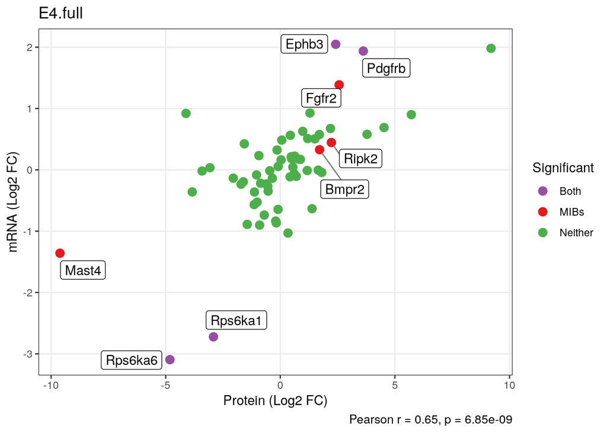

```r
# Change for each
corr_comp <- comps_combined[1,]

# Import L2FC for mRNA and MIBS
RNA_LFC <- data.frame(comp_list_oi_DE2_filt[corr_comp[,"comp_name_mRNA"]])
MIBs_LFC <- data.frame(comp_list_oi_limma_filt[corr_comp[,"comp_protein"]])

# row.names to column
RNA_LFC$genes <- row.names(RNA_LFC)
MIBs_LFC$genes <- row.names(MIBs_LFC)

# Join RNA and MIBs
proteo.transcriptomic_LFC <- left_join(RNA_LFC,MIBs_LFC , by= c("genes"="genes"))

# Generate labels
proteo.transcriptomic_LFC$mRNA_sig <- ifelse(proteo.transcriptomic_LFC[[grep("padj",colnames(proteo.transcriptomic_LFC),value = T)]] < 0.05, "Yes", "No")
proteo.transcriptomic_LFC$MIB_sig <- ifelse(proteo.transcriptomic_LFC[[grep("adj.P.Val",colnames(proteo.transcriptomic_LFC),value = T)]]< 0.05, "Yes", "No")
proteo.transcriptomic_LFC$mRNA_dir <- ifelse(proteo.transcriptomic_LFC[[grep("log2FoldChange",colnames(proteo.transcriptomic_LFC),value = T)]] < 0, "Down", "Up")
proteo.transcriptomic_LFC$MIB_dir <- ifelse(proteo.transcriptomic_LFC[[grep("logFC",colnames(proteo.transcriptomic_LFC),value = T)]] < 0, "Down", "Up")

# Generate labels
proteo.transcriptomic_LFC$corr <-
    ifelse((proteo.transcriptomic_LFC$MIB_sig == "Yes" &
              proteo.transcriptomic_LFC$mRNA_sig == "Yes"),
           "Both",
           ifelse((proteo.transcriptomic_LFC$MIB_sig == "Yes" &
                     proteo.transcriptomic_LFC$mRNA_sig == "No"),
                  "MIBs",
                  ifelse((proteo.transcriptomic_LFC$MIB_sig == "No" &
                            proteo.transcriptomic_LFC$mRNA_sig == "Yes"),
                         "mRNA",
                         "Neither"
                  )
           )
    )

# Label Neither
proteo.transcriptomic_LFC$corr[is.na(proteo.transcriptomic_LFC$corr)] <- "Neither"

# Convert to factors
proteo.transcriptomic_LFC$mRNA_sig <- as.factor(proteo.transcriptomic_LFC$mRNA_sig)
proteo.transcriptomic_LFC$MIB_sig <- as.factor(proteo.transcriptomic_LFC$MIB_sig)
proteo.transcriptomic_LFC$mRNA_dir <- as.factor(proteo.transcriptomic_LFC$mRNA_dir)
proteo.transcriptomic_LFC$MIB_dir <- as.factor(proteo.transcriptomic_LFC$MIB_dir)
proteo.transcriptomic_LFC$corr <- as.factor(proteo.transcriptomic_LFC$corr)

# Rename Columns
names(proteo.transcriptomic_LFC)[grep("logFC",colnames(proteo.transcriptomic_LFC))] <- "MIBs"
names(proteo.transcriptomic_LFC)[grep("log2FoldChange",colnames(proteo.transcriptomic_LFC))] <- "RNA"

# Calculate correlation
# Perform correlation test
corr_test <- cor.test(proteo.transcriptomic_LFC$MIBs, proteo.transcriptomic_LFC$RNA,
                      method = "pearson", use = "complete.obs")

# Extract values
# Correlation coefficient
corr_val <- corr_test$estimate
# P-value
p_val    <- corr_test$p.value

# Calculate annotation positions
x_pos <- max(proteo.transcriptomic_LFC$MIBs, na.rm = TRUE)*(.60)
y_pos <- min(proteo.transcriptomic_LFC$RNA, na.rm = TRUE)*(.95)

# Generate Graph
corr_plot <- ggplot(proteo.transcriptomic_LFC, aes(x = MIBs , y = RNA)) +
    geom_point(aes(color = corr), size = 3) +
    geom_label_repel(
      aes(
        label = ifelse((MIB_sig == "Yes" | mRNA_sig == "Yes"),
          as.character(genes),
          ''
        )
      ),
      box.padding   = 0.35,
      point.padding = 0.5,
      segment.color = 'grey50',
      max.overlaps = 30
    ) +
    labs(x = 'Protein (Log2 FC)', y ='mRNA (Log2 FC)' ) +
    ggtitle(paste0(corr_comp["comp_num_protein"])) +
    guides(fill = guide_legend(reverse = TRUE)) +
    scale_color_manual(
      "Significant",
      values = c(
        "Both" = "#984EA3",
        "MIBs" = "#E41A1C",
        "mRNA" = "#377EB8",
        "Neither" = "#4DAF4A"
      )
    ) +
  labs(caption = paste0("Pearson r = ", round(corr_val, 2), ", p = ", signif(p_val, 3))) +
    theme_bw() +
    theme(legend.position = 'right',
          plot.caption = element_text(size = 10)) +
    theme(panel.grid.minor = element_blank())

corr_plot
```

```r
# Save graph
ggsave(paste0(figures_dir,corr_comp["comp_num_protein"],"_correlation_scatter_plot.pdf"),
       plot = corr_plot,
       dpi = 300)
```

#### 2

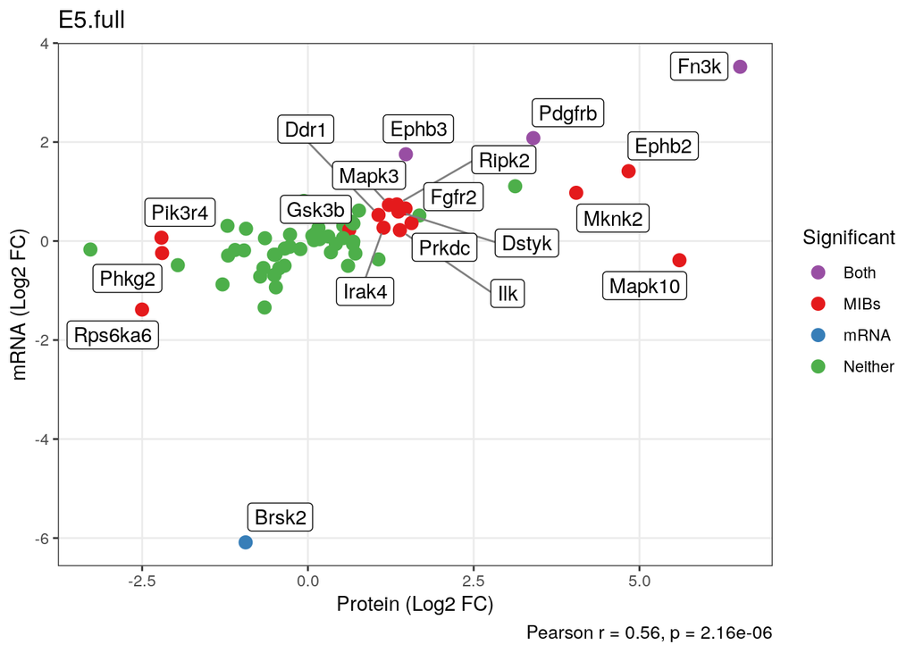

```r
# Change for each
corr_comp <- comps_combined[2,]

# Import L2FC for mRNA and MIBS
RNA_LFC <- data.frame(comp_list_oi_DE2_filt[corr_comp[,"comp_name_mRNA"]])
MIBs_LFC <- data.frame(comp_list_oi_limma_filt[corr_comp[,"comp_protein"]])

# row.names to column
RNA_LFC$genes <- row.names(RNA_LFC)
MIBs_LFC$genes <- row.names(MIBs_LFC)

# Join RNA and MIBs
proteo.transcriptomic_LFC <- left_join(RNA_LFC,MIBs_LFC , by= c("genes"="genes"))

# Generate labels
proteo.transcriptomic_LFC$mRNA_sig <- ifelse(proteo.transcriptomic_LFC[[grep("padj",colnames(proteo.transcriptomic_LFC),value = T)]] < 0.05, "Yes", "No")
proteo.transcriptomic_LFC$MIB_sig <- ifelse(proteo.transcriptomic_LFC[[grep("adj.P.Val",colnames(proteo.transcriptomic_LFC),value = T)]]< 0.05, "Yes", "No")
proteo.transcriptomic_LFC$mRNA_dir <- ifelse(proteo.transcriptomic_LFC[[grep("log2FoldChange",colnames(proteo.transcriptomic_LFC),value = T)]] < 0, "Down", "Up")
proteo.transcriptomic_LFC$MIB_dir <- ifelse(proteo.transcriptomic_LFC[[grep("logFC",colnames(proteo.transcriptomic_LFC),value = T)]] < 0, "Down", "Up")

# Generate labels
proteo.transcriptomic_LFC$corr <-
    ifelse((proteo.transcriptomic_LFC$MIB_sig == "Yes" &
              proteo.transcriptomic_LFC$mRNA_sig == "Yes"),
           "Both",
           ifelse((proteo.transcriptomic_LFC$MIB_sig == "Yes" &
                     proteo.transcriptomic_LFC$mRNA_sig == "No"),
                  "MIBs",
                  ifelse((proteo.transcriptomic_LFC$MIB_sig == "No" &
                            proteo.transcriptomic_LFC$mRNA_sig == "Yes"),
                         "mRNA",
                         "Neither"
                  )
           )
    )

# Label Neither
proteo.transcriptomic_LFC$corr[is.na(proteo.transcriptomic_LFC$corr)] <- "Neither"

# # Label kinase receptors
# proteo.transcriptomic_LFC$Receptor <-ifelse(proteo.transcriptomic_LFC$gene %in% Heatmap_GOI_df$gene_symbol, "Yes","No")

# Convert to factors
proteo.transcriptomic_LFC$mRNA_sig <- as.factor(proteo.transcriptomic_LFC$mRNA_sig)
proteo.transcriptomic_LFC$MIB_sig <- as.factor(proteo.transcriptomic_LFC$MIB_sig)
proteo.transcriptomic_LFC$mRNA_dir <- as.factor(proteo.transcriptomic_LFC$mRNA_dir)
proteo.transcriptomic_LFC$MIB_dir <- as.factor(proteo.transcriptomic_LFC$MIB_dir)
proteo.transcriptomic_LFC$corr <- as.factor(proteo.transcriptomic_LFC$corr)

# Rename Columns
names(proteo.transcriptomic_LFC)[grep("logFC",colnames(proteo.transcriptomic_LFC))] <- "MIBs"
names(proteo.transcriptomic_LFC)[grep("log2FoldChange",colnames(proteo.transcriptomic_LFC))] <- "RNA"

# Calculate correlation
# Perform correlation test
corr_test <- cor.test(proteo.transcriptomic_LFC$MIBs, proteo.transcriptomic_LFC$RNA,
                      method = "pearson", use = "complete.obs")

# Extract values
# Correlation coefficient
corr_val <- corr_test$estimate
# P-value
p_val    <- corr_test$p.value

# Calculate annotation positions
x_pos <- max(proteo.transcriptomic_LFC$MIBs, na.rm = TRUE)*(.60)
y_pos <- min(proteo.transcriptomic_LFC$RNA, na.rm = TRUE)*(.95)

# Generate Graph
corr_plot <- ggplot(proteo.transcriptomic_LFC, aes(x = MIBs , y = RNA)) +
    geom_point(aes(color = corr), size = 3) +
    geom_label_repel(
      aes(
        label = ifelse((MIB_sig == "Yes" | mRNA_sig == "Yes"),
          as.character(genes),
          ''
        )
      ),
      box.padding   = 0.35,
      point.padding = 0.5,
      segment.color = 'grey50',
      max.overlaps = 30
    ) +
    labs(x = 'Protein (Log2 FC)', y ='mRNA (Log2 FC)' ) +
    ggtitle(paste0(corr_comp["comp_num_protein"])) +
    guides(fill = guide_legend(reverse = TRUE)) +
    scale_color_manual(
      "Significant",
      values = c(
        "Both" = "#984EA3",
        "MIBs" = "#E41A1C",
        "mRNA" = "#377EB8",
        "Neither" = "#4DAF4A"
      )
    ) +
  labs(caption = paste0("Pearson r = ", round(corr_val, 2), ", p = ", signif(p_val, 3))) +
    theme_bw() +
    theme(legend.position = 'right',
          plot.caption = element_text(size = 10)) +
    theme(panel.grid.minor = element_blank())

corr_plot
```

```r
# Save graph
ggsave(paste0(figures_dir,corr_comp["comp_num_protein"],"_correlation_scatter_plot.pdf"),
       plot = corr_plot,
       dpi = 300)
```

#### 3

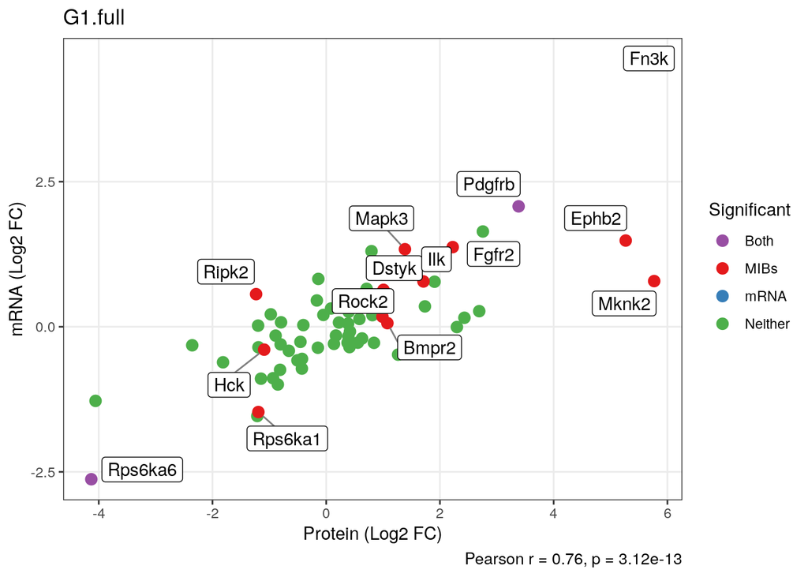

```r
# Change for each
corr_comp <- comps_combined[3,]

# Import L2FC for mRNA and MIBS
RNA_LFC <- data.frame(comp_list_oi_DE2_filt[corr_comp[,"comp_name_mRNA"]])
MIBs_LFC <- data.frame(comp_list_oi_limma_filt[corr_comp[,"comp_protein"]])

# row.names to column
RNA_LFC$genes <- row.names(RNA_LFC)
MIBs_LFC$genes <- row.names(MIBs_LFC)

# Join RNA and MIBs
proteo.transcriptomic_LFC <- left_join(RNA_LFC,MIBs_LFC , by= c("genes"="genes"))

# Generate labels
proteo.transcriptomic_LFC$mRNA_sig <- ifelse(proteo.transcriptomic_LFC[[grep("padj",colnames(proteo.transcriptomic_LFC),value = T)]] < 0.05, "Yes", "No")
proteo.transcriptomic_LFC$MIB_sig <- ifelse(proteo.transcriptomic_LFC[[grep("adj.P.Val",colnames(proteo.transcriptomic_LFC),value = T)]]< 0.05, "Yes", "No")
proteo.transcriptomic_LFC$mRNA_dir <- ifelse(proteo.transcriptomic_LFC[[grep("log2FoldChange",colnames(proteo.transcriptomic_LFC),value = T)]] < 0, "Down", "Up")
proteo.transcriptomic_LFC$MIB_dir <- ifelse(proteo.transcriptomic_LFC[[grep("logFC",colnames(proteo.transcriptomic_LFC),value = T)]] < 0, "Down", "Up")

# Generate labels
proteo.transcriptomic_LFC$corr <-
    ifelse((proteo.transcriptomic_LFC$MIB_sig == "Yes" &
              proteo.transcriptomic_LFC$mRNA_sig == "Yes"),
           "Both",
           ifelse((proteo.transcriptomic_LFC$MIB_sig == "Yes" &
                     proteo.transcriptomic_LFC$mRNA_sig == "No"),
                  "MIBs",
                  ifelse((proteo.transcriptomic_LFC$MIB_sig == "No" &
                            proteo.transcriptomic_LFC$mRNA_sig == "Yes"),
                         "mRNA",
                         "Neither"
                  )
           )
    )

# Label Neither
proteo.transcriptomic_LFC$corr[is.na(proteo.transcriptomic_LFC$corr)] <- "Neither"

# # Label kinase receptors
# proteo.transcriptomic_LFC$Receptor <-ifelse(proteo.transcriptomic_LFC$gene %in% Heatmap_GOI_df$gene_symbol, "Yes","No")

# Convert to factors
proteo.transcriptomic_LFC$mRNA_sig <- as.factor(proteo.transcriptomic_LFC$mRNA_sig)
proteo.transcriptomic_LFC$MIB_sig <- as.factor(proteo.transcriptomic_LFC$MIB_sig)
proteo.transcriptomic_LFC$mRNA_dir <- as.factor(proteo.transcriptomic_LFC$mRNA_dir)
proteo.transcriptomic_LFC$MIB_dir <- as.factor(proteo.transcriptomic_LFC$MIB_dir)
proteo.transcriptomic_LFC$corr <- as.factor(proteo.transcriptomic_LFC$corr)

# Rename Columns
names(proteo.transcriptomic_LFC)[grep("logFC",colnames(proteo.transcriptomic_LFC))] <- "MIBs"
names(proteo.transcriptomic_LFC)[grep("log2FoldChange",colnames(proteo.transcriptomic_LFC))] <- "RNA"

# Calculate correlation
# Perform correlation test
corr_test <- cor.test(proteo.transcriptomic_LFC$MIBs, proteo.transcriptomic_LFC$RNA,
                      method = "pearson", use = "complete.obs")

# Extract values
# Correlation coefficient
corr_val <- corr_test$estimate
# P-value
p_val    <- corr_test$p.value

# Calculate annotation positions
x_pos <- max(proteo.transcriptomic_LFC$MIBs, na.rm = TRUE)*(.60)
y_pos <- min(proteo.transcriptomic_LFC$RNA, na.rm = TRUE)*(.95)

# Generate Graph
corr_plot <- ggplot(proteo.transcriptomic_LFC, aes(x = MIBs , y = RNA)) +
    geom_point(aes(color = corr), size = 3) +
    geom_label_repel(
      aes(
        label = ifelse((MIB_sig == "Yes" | mRNA_sig == "Yes"),
          as.character(genes),
          ''
        )
      ),
      box.padding   = 0.35,
      point.padding = 0.5,
      segment.color = 'grey50',
      max.overlaps = 30
    ) +
    labs(x = 'Protein (Log2 FC)', y ='mRNA (Log2 FC)' ) +
    ggtitle(paste0(corr_comp["comp_num_protein"])) +
    guides(fill = guide_legend(reverse = TRUE)) +
    scale_color_manual(
      "Significant",
      values = c(
        "Both" = "#984EA3",
        "MIBs" = "#E41A1C",
        "mRNA" = "#377EB8",
        "Neither" = "#4DAF4A"
      )
    ) +
  labs(caption = paste0("Pearson r = ", round(corr_val, 2), ", p = ", signif(p_val, 3))) +
  theme_bw() +
theme(legend.position = 'right',
          plot.caption = element_text(size = 10)) +
    theme(panel.grid.minor = element_blank())

corr_plot
```

```r
# Save graph
ggsave(paste0(figures_dir,corr_comp["comp_num_protein"],"_correlation_scatter_plot.pdf"),
       plot = corr_plot,
       dpi = 300)
```

#### 4

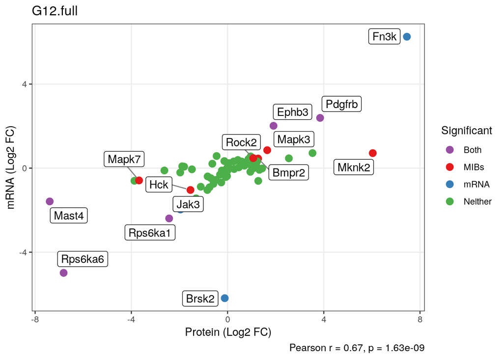

```r
# Change for each
corr_comp <- comps_combined[4,]

# Import L2FC for mRNA and MIBS
RNA_LFC <- data.frame(comp_list_oi_DE2_filt[corr_comp[,"comp_name_mRNA"]])
MIBs_LFC <- data.frame(comp_list_oi_limma_filt[corr_comp[,"comp_protein"]])

# row.names to column
RNA_LFC$genes <- row.names(RNA_LFC)
MIBs_LFC$genes <- row.names(MIBs_LFC)

# Join RNA and MIBs
proteo.transcriptomic_LFC <- left_join(RNA_LFC,MIBs_LFC , by= c("genes"="genes"))

# Generate labels
proteo.transcriptomic_LFC$mRNA_sig <- ifelse(proteo.transcriptomic_LFC[[grep("padj",colnames(proteo.transcriptomic_LFC),value = T)]] < 0.05, "Yes", "No")
proteo.transcriptomic_LFC$MIB_sig <- ifelse(proteo.transcriptomic_LFC[[grep("adj.P.Val",colnames(proteo.transcriptomic_LFC),value = T)]]< 0.05, "Yes", "No")
proteo.transcriptomic_LFC$mRNA_dir <- ifelse(proteo.transcriptomic_LFC[[grep("log2FoldChange",colnames(proteo.transcriptomic_LFC),value = T)]] < 0, "Down", "Up")
proteo.transcriptomic_LFC$MIB_dir <- ifelse(proteo.transcriptomic_LFC[[grep("logFC",colnames(proteo.transcriptomic_LFC),value = T)]] < 0, "Down", "Up")

# Generate labels
proteo.transcriptomic_LFC$corr <-
    ifelse((proteo.transcriptomic_LFC$MIB_sig == "Yes" &
              proteo.transcriptomic_LFC$mRNA_sig == "Yes"),
           "Both",
           ifelse((proteo.transcriptomic_LFC$MIB_sig == "Yes" &
                     proteo.transcriptomic_LFC$mRNA_sig == "No"),
                  "MIBs",
                  ifelse((proteo.transcriptomic_LFC$MIB_sig == "No" &
                            proteo.transcriptomic_LFC$mRNA_sig == "Yes"),
                         "mRNA",
                         "Neither"
                  )
           )
    )

# Label Neither
proteo.transcriptomic_LFC$corr[is.na(proteo.transcriptomic_LFC$corr)] <- "Neither"

# # Label kinase receptors
# proteo.transcriptomic_LFC$Receptor <-ifelse(proteo.transcriptomic_LFC$gene %in% Heatmap_GOI_df$gene_symbol, "Yes","No")

# Convert to factors
proteo.transcriptomic_LFC$mRNA_sig <- as.factor(proteo.transcriptomic_LFC$mRNA_sig)
proteo.transcriptomic_LFC$MIB_sig <- as.factor(proteo.transcriptomic_LFC$MIB_sig)
proteo.transcriptomic_LFC$mRNA_dir <- as.factor(proteo.transcriptomic_LFC$mRNA_dir)
proteo.transcriptomic_LFC$MIB_dir <- as.factor(proteo.transcriptomic_LFC$MIB_dir)
proteo.transcriptomic_LFC$corr <- as.factor(proteo.transcriptomic_LFC$corr)

# Rename Columns
names(proteo.transcriptomic_LFC)[grep("logFC",colnames(proteo.transcriptomic_LFC))] <- "MIBs"
names(proteo.transcriptomic_LFC)[grep("log2FoldChange",colnames(proteo.transcriptomic_LFC))] <- "RNA"

# Calculate correlation
# Perform correlation test
corr_test <- cor.test(proteo.transcriptomic_LFC$MIBs, proteo.transcriptomic_LFC$RNA,
                      method = "pearson", use = "complete.obs")

# Extract values
# Correlation coefficient
corr_val <- corr_test$estimate
# P-value
p_val    <- corr_test$p.value

# Calculate annotation positions
x_pos <- max(proteo.transcriptomic_LFC$MIBs, na.rm = TRUE)*(.60)
y_pos <- min(proteo.transcriptomic_LFC$RNA, na.rm = TRUE)*(.95)

# Generate Graph
corr_plot <- ggplot(proteo.transcriptomic_LFC, aes(x = MIBs , y = RNA)) +
    geom_point(aes(color = corr), size = 3) +
    geom_label_repel(
      aes(
        label = ifelse((MIB_sig == "Yes" | mRNA_sig == "Yes"),
          as.character(genes),
          ''
        )
      ),
      box.padding   = 0.35,
      point.padding = 0.5,
      segment.color = 'grey50',
      max.overlaps = 30
    ) +
    labs(x = 'Protein (Log2 FC)', y ='mRNA (Log2 FC)' ) +
    ggtitle(paste0(corr_comp["comp_num_protein"])) +
    guides(fill = guide_legend(reverse = TRUE)) +
    scale_color_manual(
      "Significant",
      values = c(
        "Both" = "#984EA3",
        "MIBs" = "#E41A1C",
        "mRNA" = "#377EB8",
        "Neither" = "#4DAF4A"
      )
    ) +
   labs(caption = paste0("Pearson r = ", round(corr_val, 2), ", p = ", signif(p_val, 3))) +
    theme_bw() +
    theme(legend.position = 'right',
          plot.caption = element_text(size = 10)) +
    theme(panel.grid.minor = element_blank())

corr_plot
```

```r
# Save graph
ggsave(paste0(figures_dir,corr_comp["comp_num_protein"],"_correlation_scatter_plot.pdf"),
       plot = corr_plot,
       dpi = 300)
```

#### 5

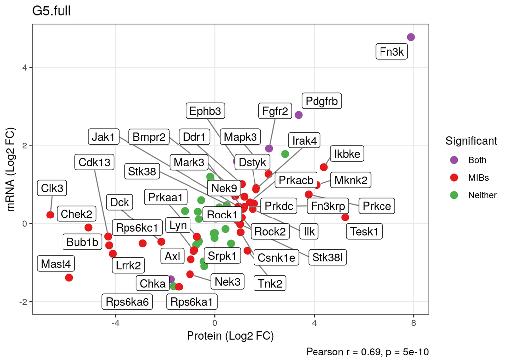

```r
# Change for each
corr_comp <- comps_combined[5,]

# Import L2FC for mRNA and MIBS
RNA_LFC <- data.frame(comp_list_oi_DE2_filt[corr_comp[,"comp_name_mRNA"]])
MIBs_LFC <- data.frame(comp_list_oi_limma_filt[corr_comp[,"comp_protein"]])

# row.names to column
RNA_LFC$genes <- row.names(RNA_LFC)
MIBs_LFC$genes <- row.names(MIBs_LFC)

# Join RNA and MIBs
proteo.transcriptomic_LFC <- left_join(RNA_LFC,MIBs_LFC , by= c("genes"="genes"))

# Generate labels
proteo.transcriptomic_LFC$mRNA_sig <- ifelse(proteo.transcriptomic_LFC[[grep("padj",colnames(proteo.transcriptomic_LFC),value = T)]] < 0.05, "Yes", "No")
proteo.transcriptomic_LFC$MIB_sig <- ifelse(proteo.transcriptomic_LFC[[grep("adj.P.Val",colnames(proteo.transcriptomic_LFC),value = T)]]< 0.05, "Yes", "No")
proteo.transcriptomic_LFC$mRNA_dir <- ifelse(proteo.transcriptomic_LFC[[grep("log2FoldChange",colnames(proteo.transcriptomic_LFC),value = T)]] < 0, "Down", "Up")
proteo.transcriptomic_LFC$MIB_dir <- ifelse(proteo.transcriptomic_LFC[[grep("logFC",colnames(proteo.transcriptomic_LFC),value = T)]] < 0, "Down", "Up")

# Generate labels
proteo.transcriptomic_LFC$corr <-
    ifelse((proteo.transcriptomic_LFC$MIB_sig == "Yes" &
              proteo.transcriptomic_LFC$mRNA_sig == "Yes"),
           "Both",
           ifelse((proteo.transcriptomic_LFC$MIB_sig == "Yes" &
                     proteo.transcriptomic_LFC$mRNA_sig == "No"),
                  "MIBs",
                  ifelse((proteo.transcriptomic_LFC$MIB_sig == "No" &
                            proteo.transcriptomic_LFC$mRNA_sig == "Yes"),
                         "mRNA",
                         "Neither"
                  )
           )
    )

# Label Neither
proteo.transcriptomic_LFC$corr[is.na(proteo.transcriptomic_LFC$corr)] <- "Neither"

# # Label kinase receptors
# proteo.transcriptomic_LFC$Receptor <-ifelse(proteo.transcriptomic_LFC$gene %in% Heatmap_GOI_df$gene_symbol, "Yes","No")

# Convert to factors
proteo.transcriptomic_LFC$mRNA_sig <- as.factor(proteo.transcriptomic_LFC$mRNA_sig)
proteo.transcriptomic_LFC$MIB_sig <- as.factor(proteo.transcriptomic_LFC$MIB_sig)
proteo.transcriptomic_LFC$mRNA_dir <- as.factor(proteo.transcriptomic_LFC$mRNA_dir)
proteo.transcriptomic_LFC$MIB_dir <- as.factor(proteo.transcriptomic_LFC$MIB_dir)
proteo.transcriptomic_LFC$corr <- as.factor(proteo.transcriptomic_LFC$corr)

# Rename Columns
names(proteo.transcriptomic_LFC)[grep("logFC",colnames(proteo.transcriptomic_LFC))] <- "MIBs"
names(proteo.transcriptomic_LFC)[grep("log2FoldChange",colnames(proteo.transcriptomic_LFC))] <- "RNA"

# Calculate correlation
# Perform correlation test
corr_test <- cor.test(proteo.transcriptomic_LFC$MIBs, proteo.transcriptomic_LFC$RNA,
                      method = "pearson", use = "complete.obs")

# Extract values
# Correlation coefficient
corr_val <- corr_test$estimate
# P-value
p_val    <- corr_test$p.value

# Calculate annotation positions
x_pos <- max(proteo.transcriptomic_LFC$MIBs, na.rm = TRUE)*(.60)
y_pos <- min(proteo.transcriptomic_LFC$RNA, na.rm = TRUE)*(.95)

# Generate Graph
corr_plot <- ggplot(proteo.transcriptomic_LFC, aes(x = MIBs , y = RNA)) +
    geom_point(aes(color = corr), size = 3) +
    geom_label_repel(
      aes(
        label = ifelse((MIB_sig == "Yes" | mRNA_sig == "Yes"),
          as.character(genes),
          ''
        )
      ),
      box.padding   = 0.35,
      point.padding = 0.5,
      segment.color = 'grey50',
      max.overlaps = 30
    ) +
    labs(x = 'Protein (Log2 FC)', y ='mRNA (Log2 FC)' ) +
    ggtitle(paste0(corr_comp["comp_num_protein"])) +
    guides(fill = guide_legend(reverse = TRUE)) +
    scale_color_manual(
      "Significant",
      values = c(
        "Both" = "#984EA3",
        "MIBs" = "#E41A1C",
        "mRNA" = "#377EB8",
        "Neither" = "#4DAF4A"
      )
    ) +
    labs(caption = paste0("Pearson r = ", round(corr_val, 2), ", p = ", signif(p_val, 3))) +
    theme_bw() +
    theme(legend.position = 'right',
          plot.caption = element_text(size = 10)) +
    theme(panel.grid.minor = element_blank())

corr_plot
```

```r
# Save graph
ggsave(paste0(figures_dir,corr_comp["comp_num_protein"],"_correlation_scatter_plot.pdf"),
       plot = corr_plot,
       dpi = 300)
```

#### 6

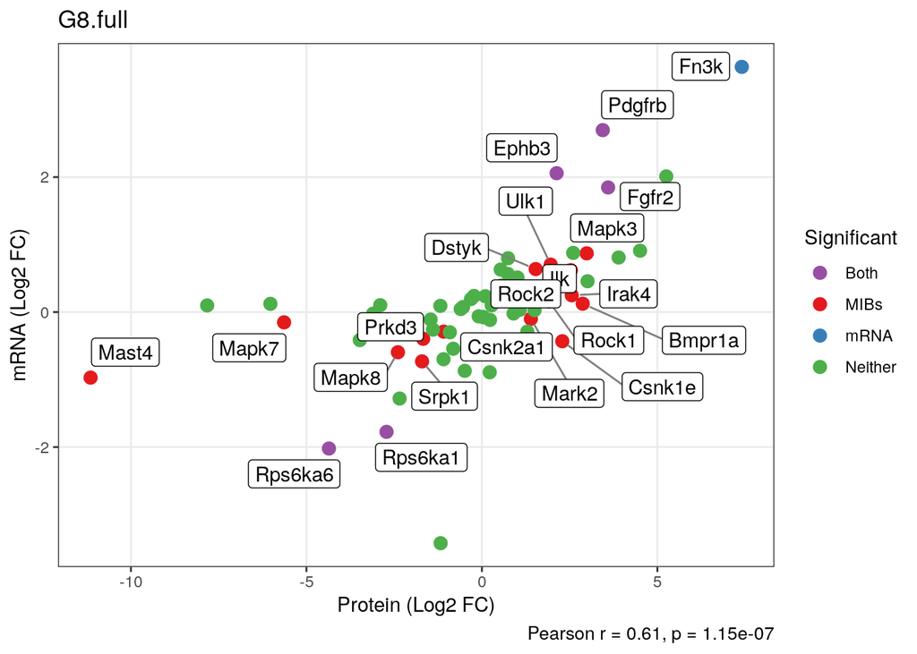

```r
# Change for each
corr_comp <- comps_combined[6,]

# Import L2FC for mRNA and MIBS
RNA_LFC <- data.frame(comp_list_oi_DE2_filt[corr_comp[,"comp_name_mRNA"]])
MIBs_LFC <- data.frame(comp_list_oi_limma_filt[corr_comp[,"comp_protein"]])

# row.names to column
RNA_LFC$genes <- row.names(RNA_LFC)
MIBs_LFC$genes <- row.names(MIBs_LFC)

# Join RNA and MIBs
proteo.transcriptomic_LFC <- left_join(RNA_LFC,MIBs_LFC , by= c("genes"="genes"))

# Generate labels
proteo.transcriptomic_LFC$mRNA_sig <- ifelse(proteo.transcriptomic_LFC[[grep("padj",colnames(proteo.transcriptomic_LFC),value = T)]] < 0.05, "Yes", "No")
proteo.transcriptomic_LFC$MIB_sig <- ifelse(proteo.transcriptomic_LFC[[grep("adj.P.Val",colnames(proteo.transcriptomic_LFC),value = T)]]< 0.05, "Yes", "No")
proteo.transcriptomic_LFC$mRNA_dir <- ifelse(proteo.transcriptomic_LFC[[grep("log2FoldChange",colnames(proteo.transcriptomic_LFC),value = T)]] < 0, "Down", "Up")
proteo.transcriptomic_LFC$MIB_dir <- ifelse(proteo.transcriptomic_LFC[[grep("logFC",colnames(proteo.transcriptomic_LFC),value = T)]] < 0, "Down", "Up")

# Generate labels
proteo.transcriptomic_LFC$corr <-
    ifelse((proteo.transcriptomic_LFC$MIB_sig == "Yes" &
              proteo.transcriptomic_LFC$mRNA_sig == "Yes"),
           "Both",
           ifelse((proteo.transcriptomic_LFC$MIB_sig == "Yes" &
                     proteo.transcriptomic_LFC$mRNA_sig == "No"),
                  "MIBs",
                  ifelse((proteo.transcriptomic_LFC$MIB_sig == "No" &
                            proteo.transcriptomic_LFC$mRNA_sig == "Yes"),
                         "mRNA",
                         "Neither"
                  )
           )
    )

# Label Neither
proteo.transcriptomic_LFC$corr[is.na(proteo.transcriptomic_LFC$corr)] <- "Neither"

# # Label kinase receptors
# proteo.transcriptomic_LFC$Receptor <-ifelse(proteo.transcriptomic_LFC$gene %in% Heatmap_GOI_df$gene_symbol, "Yes","No")

# Convert to factors
proteo.transcriptomic_LFC$mRNA_sig <- as.factor(proteo.transcriptomic_LFC$mRNA_sig)
proteo.transcriptomic_LFC$MIB_sig <- as.factor(proteo.transcriptomic_LFC$MIB_sig)
proteo.transcriptomic_LFC$mRNA_dir <- as.factor(proteo.transcriptomic_LFC$mRNA_dir)
proteo.transcriptomic_LFC$MIB_dir <- as.factor(proteo.transcriptomic_LFC$MIB_dir)
proteo.transcriptomic_LFC$corr <- as.factor(proteo.transcriptomic_LFC$corr)

# Rename Columns
names(proteo.transcriptomic_LFC)[grep("logFC",colnames(proteo.transcriptomic_LFC))] <- "MIBs"
names(proteo.transcriptomic_LFC)[grep("log2FoldChange",colnames(proteo.transcriptomic_LFC))] <- "RNA"

# Calculate correlation
# Perform correlation test
corr_test <- cor.test(proteo.transcriptomic_LFC$MIBs, proteo.transcriptomic_LFC$RNA,
                      method = "pearson", use = "complete.obs")

# Extract values
# Correlation coefficient
corr_val <- corr_test$estimate
# P-value
p_val    <- corr_test$p.value

# Calculate annotation positions
x_pos <- max(proteo.transcriptomic_LFC$MIBs, na.rm = TRUE)*(.60)
y_pos <- min(proteo.transcriptomic_LFC$RNA, na.rm = TRUE)*(.95)

# Generate Graph
corr_plot <- ggplot(proteo.transcriptomic_LFC, aes(x = MIBs , y = RNA)) +
    geom_point(aes(color = corr), size = 3) +
    geom_label_repel(
      aes(
        label = ifelse((MIB_sig == "Yes" | mRNA_sig == "Yes"),
          as.character(genes),
          ''
        )
      ),
      box.padding   = 0.35,
      point.padding = 0.5,
      segment.color = 'grey50',
      max.overlaps = 30
    ) +
    labs(x = 'Protein (Log2 FC)', y ='mRNA (Log2 FC)' ) +
    ggtitle(paste0(corr_comp["comp_num_protein"])) +
    guides(fill = guide_legend(reverse = TRUE)) +
    scale_color_manual(
      "Significant",
      values = c(
        "Both" = "#984EA3",
        "MIBs" = "#E41A1C",
        "mRNA" = "#377EB8",
        "Neither" = "#4DAF4A"
      )
    ) +
  labs(caption = paste0("Pearson r = ", round(corr_val, 2), ", p = ", signif(p_val, 3))) +
    theme_bw() +
    theme(legend.position = 'right',
          plot.caption = element_text(size = 10)) +
    theme(panel.grid.minor = element_blank())

corr_plot
```

```r
# Save graph
ggsave(paste0(figures_dir,corr_comp["comp_num_protein"],"_correlation_scatter_plot.pdf"),
       plot = corr_plot,
       dpi = 300)
```

## ss

### Import ss DE res

```r
fig.label <- paste0("Baseline_sig_corr")
figures_dir <- paste0(Data,"Figures/",fig.label,"/")
dir.create(figures_dir)
# limma results direct
output_dir_res <- paste0(Data,"Output/MIB-BL/DEP_Bl_Res_ss/","Limma_res/")

# Summarize of limma comparisions
comps_limma <- read.csv(paste0(Data,"Output/MIB-BL/DEP_Bl_Res_ss/","comps_all.csv"), row.names = 1)

# import limma res
subset_limmaRes <- list()
for (i in seq_along(row.names(comps_limma))){
  subset_limmaRes[[comps_limma$comp[i]]] <-
  read.csv(paste0(output_dir_res,"comp_",i,"_",comps_limma[i,5],".csv"), row.names = 1)
}

# Extract comps_limma of interest
coi_limma <- comps_limma[comps_limma$comp_denom %in% c("CEv3.starve"),]$comp
comp_list_oi_limma <- subset_limmaRes[names(subset_limmaRes) %in% coi_limma]

# DESEQ2 results direct
output_dir_res <- paste0(Data,"Output/RNA/dds_EDA_subset/bl_Res_ss/","DE2_res/")

# Summarize of DESEQ2 comparisions
comps_DE2 <- read.csv(paste0(Data,"Output/RNA/dds_EDA_subset/bl_Res_ss/","comps_all.csv"), row.names = 1)

# import DE2 res
subset_DE2Res <- list()
for (i in seq_along(comps_DE2$comp_name)){
  subset_DE2Res[[comps_DE2$comp_name[i]]] <-
  read.csv(paste0(output_dir_res,"comp_",i,"_",comps_DE2$comp_name[i],".csv"), row.names = 1)
}

# Extract comps_DE2 of interest
coi_DE2 <- comps_DE2[comps_DE2$comp_denom %in% c("starve_CEv3_NA_0"),]$comp_name
comp_list_oi_DE2 <- subset_DE2Res[names(subset_DE2Res) %in% coi_DE2]

# Comps combined
comps_df_limma <- comps_limma[comps_limma$comp_denom %in% c("CEv3.starve"),]
colnames(comps_df_limma) <- paste(colnames(comps_df_limma),"protein",sep = "_")
comps_df_DE2 <- comps_DE2[comps_DE2$comp_denom %in% c("starve_CEv3_NA_0"),]
colnames(comps_df_DE2) <- paste(colnames(comps_df_DE2),"mRNA",sep = "_")

# Cbind
comps_combined <- cbind(comps_df_limma,comps_df_DE2)
comps_combined
```

```
##    comp_type_protein comp_num_protein comp_denom_protein
## 7          condition        E4.starve        CEv3.starve
## 13         condition        E5.starve        CEv3.starve
## 19         condition        G1.starve        CEv3.starve
## 25         condition       G12.starve        CEv3.starve
## 31         condition        G5.starve        CEv3.starve
## 37         condition        G8.starve        CEv3.starve
##            comp_name_protein           comp_protein comp_type_mRNA
## 7   E4.starve-vs-CEv3.starve  E4.starve-CEv3.starve    serum_group
## 13  E5.starve-vs-CEv3.starve  E5.starve-CEv3.starve    serum_group
## 19  G1.starve-vs-CEv3.starve  G1.starve-CEv3.starve    serum_group
## 25 G12.starve-vs-CEv3.starve G12.starve-CEv3.starve    serum_group
## 31  G5.starve-vs-CEv3.starve  G5.starve-CEv3.starve    serum_group
## 37  G8.starve-vs-CEv3.starve  G8.starve-CEv3.starve    serum_group
##      comp_num_mRNA  comp_denom_mRNA                      comp_name_mRNA
## 7   starve_E4_NA_0 starve_CEv3_NA_0  starve_E4_NA_0-vs-starve_CEv3_NA_0
## 13  starve_E5_NA_0 starve_CEv3_NA_0  starve_E5_NA_0-vs-starve_CEv3_NA_0
## 19  starve_G1_NA_0 starve_CEv3_NA_0  starve_G1_NA_0-vs-starve_CEv3_NA_0
## 25 starve_G12_NA_0 starve_CEv3_NA_0 starve_G12_NA_0-vs-starve_CEv3_NA_0
## 31  starve_G5_NA_0 starve_CEv3_NA_0  starve_G5_NA_0-vs-starve_CEv3_NA_0
## 37  starve_G8_NA_0 starve_CEv3_NA_0  starve_G8_NA_0-vs-starve_CEv3_NA_0
```

```r
# Remove genes not in signature

# Remove protein genes not in signature
comp_list_oi_limma_filt <- lapply(comp_list_oi_limma, function(x) subset(x,row.names(x) %in% c(BL_sig$gene)))

# Remove RNA genes not in signature
comp_list_oi_DE2_filt <- lapply(comp_list_oi_DE2, function(x) subset(x,row.names(x) %in% c(BL_sig$gene)))
```

### S.7A-F

#### 1

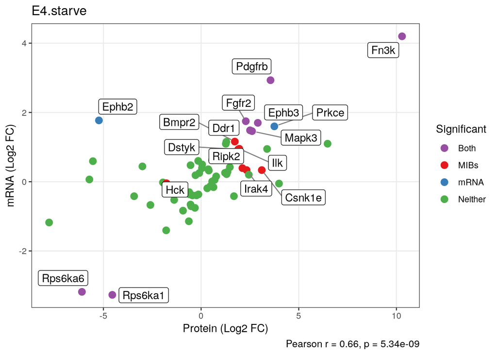

```r
# Change for each
corr_comp <- comps_combined[1,]

# Import L2FC for mRNA and MIBS
RNA_LFC <- data.frame(comp_list_oi_DE2_filt[corr_comp[,"comp_name_mRNA"]])
MIBs_LFC <- data.frame(comp_list_oi_limma_filt[corr_comp[,"comp_protein"]])

# row.names to column
RNA_LFC$genes <- row.names(RNA_LFC)
MIBs_LFC$genes <- row.names(MIBs_LFC)

# Join RNA and MIBs
proteo.transcriptomic_LFC <- left_join(RNA_LFC,MIBs_LFC , by= c("genes"="genes"))

# Generate labels
proteo.transcriptomic_LFC$mRNA_sig <- ifelse(proteo.transcriptomic_LFC[[grep("padj",colnames(proteo.transcriptomic_LFC),value = T)]] < 0.05, "Yes", "No")
proteo.transcriptomic_LFC$MIB_sig <- ifelse(proteo.transcriptomic_LFC[[grep("adj.P.Val",colnames(proteo.transcriptomic_LFC),value = T)]]< 0.05, "Yes", "No")
proteo.transcriptomic_LFC$mRNA_dir <- ifelse(proteo.transcriptomic_LFC[[grep("log2FoldChange",colnames(proteo.transcriptomic_LFC),value = T)]] < 0, "Down", "Up")
proteo.transcriptomic_LFC$MIB_dir <- ifelse(proteo.transcriptomic_LFC[[grep("logFC",colnames(proteo.transcriptomic_LFC),value = T)]] < 0, "Down", "Up")

# Generate labels
proteo.transcriptomic_LFC$corr <-
    ifelse((proteo.transcriptomic_LFC$MIB_sig == "Yes" &
              proteo.transcriptomic_LFC$mRNA_sig == "Yes"),
           "Both",
           ifelse((proteo.transcriptomic_LFC$MIB_sig == "Yes" &
                     proteo.transcriptomic_LFC$mRNA_sig == "No"),
                  "MIBs",
                  ifelse((proteo.transcriptomic_LFC$MIB_sig == "No" &
                            proteo.transcriptomic_LFC$mRNA_sig == "Yes"),
                         "mRNA",
                         "Neither"
                  )
           )
    )

# Label Neither
proteo.transcriptomic_LFC$corr[is.na(proteo.transcriptomic_LFC$corr)] <- "Neither"

# # Label kinase receptors
# proteo.transcriptomic_LFC$Receptor <-ifelse(proteo.transcriptomic_LFC$gene %in% Heatmap_GOI_df$gene_symbol, "Yes","No")

# Convert to factors
proteo.transcriptomic_LFC$mRNA_sig <- as.factor(proteo.transcriptomic_LFC$mRNA_sig)
proteo.transcriptomic_LFC$MIB_sig <- as.factor(proteo.transcriptomic_LFC$MIB_sig)
proteo.transcriptomic_LFC$mRNA_dir <- as.factor(proteo.transcriptomic_LFC$mRNA_dir)
proteo.transcriptomic_LFC$MIB_dir <- as.factor(proteo.transcriptomic_LFC$MIB_dir)
proteo.transcriptomic_LFC$corr <- as.factor(proteo.transcriptomic_LFC$corr)

# Rename Columns
names(proteo.transcriptomic_LFC)[grep("logFC",colnames(proteo.transcriptomic_LFC))] <- "MIBs"
names(proteo.transcriptomic_LFC)[grep("log2FoldChange",colnames(proteo.transcriptomic_LFC))] <- "RNA"

# Calculate correlation
# Perform correlation test
corr_test <- cor.test(proteo.transcriptomic_LFC$MIBs, proteo.transcriptomic_LFC$RNA,
                      method = "pearson", use = "complete.obs")

# Extract values
# Correlation coefficient
corr_val <- corr_test$estimate
# P-value
p_val    <- corr_test$p.value

# Calculate annotation positions
x_pos <- max(proteo.transcriptomic_LFC$MIBs, na.rm = TRUE)*(.60)
y_pos <- min(proteo.transcriptomic_LFC$RNA, na.rm = TRUE)*(.95)

# Generate Graph
corr_plot <- ggplot(proteo.transcriptomic_LFC, aes(x = MIBs , y = RNA)) +
    geom_point(aes(color = corr), size = 3) +
    geom_label_repel(
      aes(
        label = ifelse((MIB_sig == "Yes" | mRNA_sig == "Yes"),
          as.character(genes),
          ''
        )
      ),
      box.padding   = 0.35,
      point.padding = 0.5,
      segment.color = 'grey50',
      max.overlaps = 30
    ) +
    labs(x = 'Protein (Log2 FC)', y ='mRNA (Log2 FC)' ) +
    ggtitle(paste0(corr_comp["comp_num_protein"])) +
    guides(fill = guide_legend(reverse = TRUE)) +
    scale_color_manual(
      "Significant",
      values = c(
        "Both" = "#984EA3",
        "MIBs" = "#E41A1C",
        "mRNA" = "#377EB8",
        "Neither" = "#4DAF4A"
      )
    ) +
  labs(caption = paste0("Pearson r = ", round(corr_val, 2), ", p = ", signif(p_val, 3))) +
    theme_bw() +
    theme(legend.position = 'right',
          plot.caption = element_text(size = 10)) +
    theme(panel.grid.minor = element_blank())

corr_plot
```

```r
# Save graph
ggsave(paste0(figures_dir,corr_comp["comp_num_protein"],"_correlation_scatter_plot.pdf"),
       plot = corr_plot,
       dpi = 300)
```

#### 2

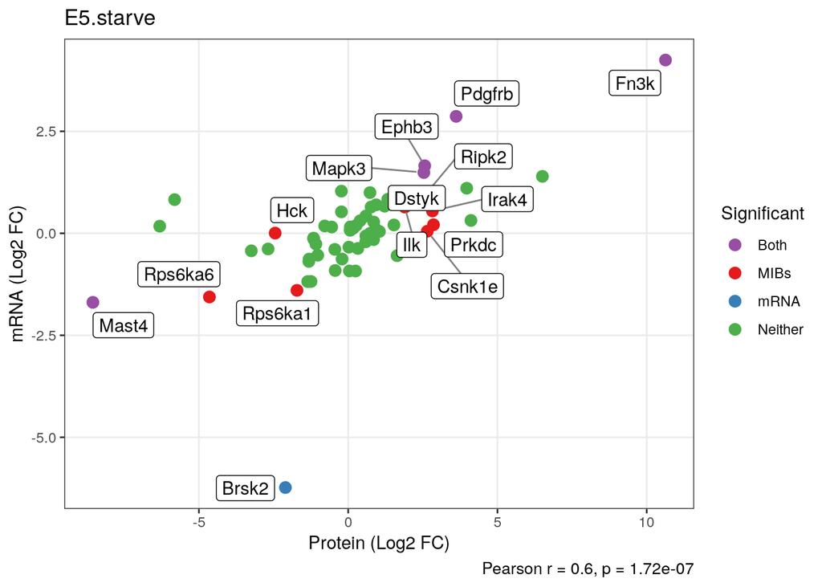

```r
# Change for each
corr_comp <- comps_combined[2,]

# Import L2FC for mRNA and MIBS
RNA_LFC <- data.frame(comp_list_oi_DE2_filt[corr_comp[,"comp_name_mRNA"]])
MIBs_LFC <- data.frame(comp_list_oi_limma_filt[corr_comp[,"comp_protein"]])

# row.names to column
RNA_LFC$genes <- row.names(RNA_LFC)
MIBs_LFC$genes <- row.names(MIBs_LFC)

# Join RNA and MIBs
proteo.transcriptomic_LFC <- left_join(RNA_LFC,MIBs_LFC , by= c("genes"="genes"))

# Generate labels
proteo.transcriptomic_LFC$mRNA_sig <- ifelse(proteo.transcriptomic_LFC[[grep("padj",colnames(proteo.transcriptomic_LFC),value = T)]] < 0.05, "Yes", "No")
proteo.transcriptomic_LFC$MIB_sig <- ifelse(proteo.transcriptomic_LFC[[grep("adj.P.Val",colnames(proteo.transcriptomic_LFC),value = T)]]< 0.05, "Yes", "No")
proteo.transcriptomic_LFC$mRNA_dir <- ifelse(proteo.transcriptomic_LFC[[grep("log2FoldChange",colnames(proteo.transcriptomic_LFC),value = T)]] < 0, "Down", "Up")
proteo.transcriptomic_LFC$MIB_dir <- ifelse(proteo.transcriptomic_LFC[[grep("logFC",colnames(proteo.transcriptomic_LFC),value = T)]] < 0, "Down", "Up")

# Generate labels
proteo.transcriptomic_LFC$corr <-
    ifelse((proteo.transcriptomic_LFC$MIB_sig == "Yes" &
              proteo.transcriptomic_LFC$mRNA_sig == "Yes"),
           "Both",
           ifelse((proteo.transcriptomic_LFC$MIB_sig == "Yes" &
                     proteo.transcriptomic_LFC$mRNA_sig == "No"),
                  "MIBs",
                  ifelse((proteo.transcriptomic_LFC$MIB_sig == "No" &
                            proteo.transcriptomic_LFC$mRNA_sig == "Yes"),
                         "mRNA",
                         "Neither"
                  )
           )
    )

# Label Neither
proteo.transcriptomic_LFC$corr[is.na(proteo.transcriptomic_LFC$corr)] <- "Neither"

# # Label kinase receptors
# proteo.transcriptomic_LFC$Receptor <-ifelse(proteo.transcriptomic_LFC$gene %in% Heatmap_GOI_df$gene_symbol, "Yes","No")

# Convert to factors
proteo.transcriptomic_LFC$mRNA_sig <- as.factor(proteo.transcriptomic_LFC$mRNA_sig)
proteo.transcriptomic_LFC$MIB_sig <- as.factor(proteo.transcriptomic_LFC$MIB_sig)
proteo.transcriptomic_LFC$mRNA_dir <- as.factor(proteo.transcriptomic_LFC$mRNA_dir)
proteo.transcriptomic_LFC$MIB_dir <- as.factor(proteo.transcriptomic_LFC$MIB_dir)
proteo.transcriptomic_LFC$corr <- as.factor(proteo.transcriptomic_LFC$corr)

# Rename Columns
names(proteo.transcriptomic_LFC)[grep("logFC",colnames(proteo.transcriptomic_LFC))] <- "MIBs"
names(proteo.transcriptomic_LFC)[grep("log2FoldChange",colnames(proteo.transcriptomic_LFC))] <- "RNA"

# Calculate correlation
# Perform correlation test
corr_test <- cor.test(proteo.transcriptomic_LFC$MIBs, proteo.transcriptomic_LFC$RNA,
                      method = "pearson", use = "complete.obs")

# Extract values
# Correlation coefficient
corr_val <- corr_test$estimate
# P-value
p_val    <- corr_test$p.value

# Calculate annotation positions
x_pos <- max(proteo.transcriptomic_LFC$MIBs, na.rm = TRUE)*(.60)
y_pos <- min(proteo.transcriptomic_LFC$RNA, na.rm = TRUE)*(.95)

# Generate Graph
corr_plot <- ggplot(proteo.transcriptomic_LFC, aes(x = MIBs , y = RNA)) +
    geom_point(aes(color = corr), size = 3) +
    geom_label_repel(
      aes(
        label = ifelse((MIB_sig == "Yes" | mRNA_sig == "Yes"),
          as.character(genes),
          ''
        )
      ),
      box.padding   = 0.35,
      point.padding = 0.5,
      segment.color = 'grey50',
      max.overlaps = 30
    ) +
    labs(x = 'Protein (Log2 FC)', y ='mRNA (Log2 FC)' ) +
    ggtitle(paste0(corr_comp["comp_num_protein"])) +
    guides(fill = guide_legend(reverse = TRUE)) +
    scale_color_manual(
      "Significant",
      values = c(
        "Both" = "#984EA3",
        "MIBs" = "#E41A1C",
        "mRNA" = "#377EB8",
        "Neither" = "#4DAF4A"
      )
    ) +
  labs(caption = paste0("Pearson r = ", round(corr_val, 2), ", p = ", signif(p_val, 3))) +
    theme_bw() +
    theme(legend.position = 'right',
          plot.caption = element_text(size = 10)) +
    theme(panel.grid.minor = element_blank())

corr_plot
```

```r
# Save graph
ggsave(paste0(figures_dir,corr_comp["comp_num_protein"],"_correlation_scatter_plot.pdf"),
       plot = corr_plot,
       dpi = 300)
```